# Visualización en el espacio - EM

Se cruzan `PAY_AMT1` a `PAY_AMT6` (montos efectivamente pagados de septiembre a abril de 2005) contra `EDUCATION`, para comparar cuánto pagaron efectivamente los clientes según su nivel educativo, mes a mes.

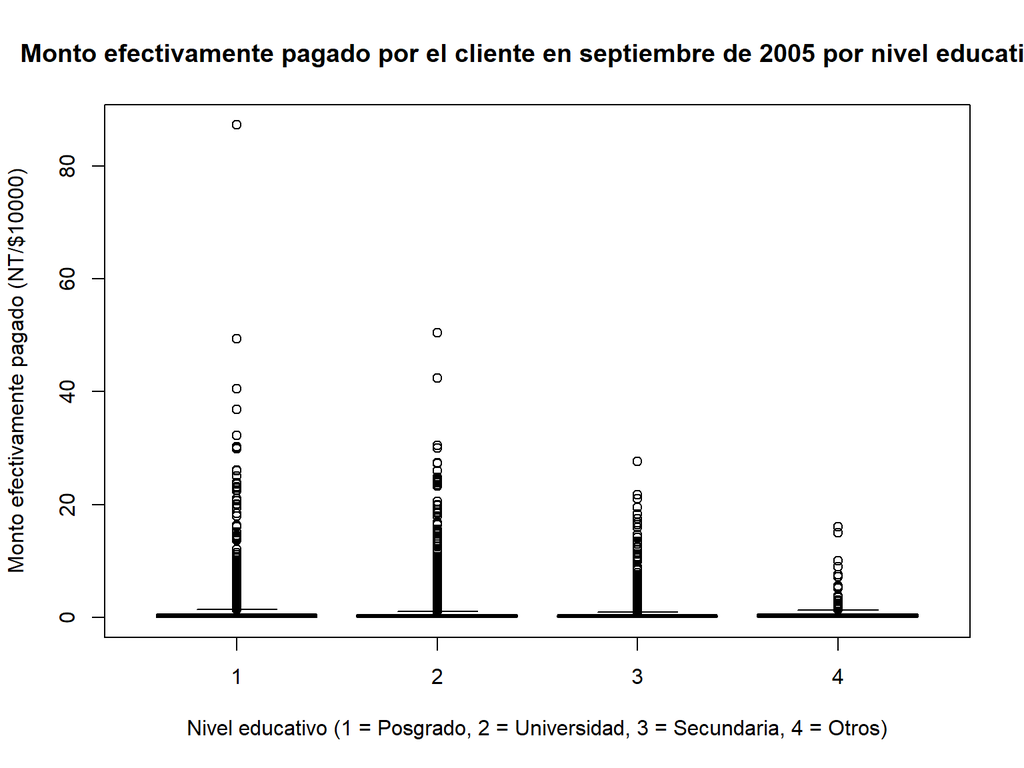

```r
boxplot(PAY_AMT1/10000 ~ EDUCATION, data = datos_credit_visu,
        main = "Monto efectivamente pagado por el cliente en septiembre de 2005 por nivel educativo",
        xlab = "Nivel educativo (1 = Posgrado, 2 = Universidad, 3 = Secundaria, 4 = Otros)", ylab = "Monto efectivamente pagado (NT/$10000)",
        col = "grey90")
```

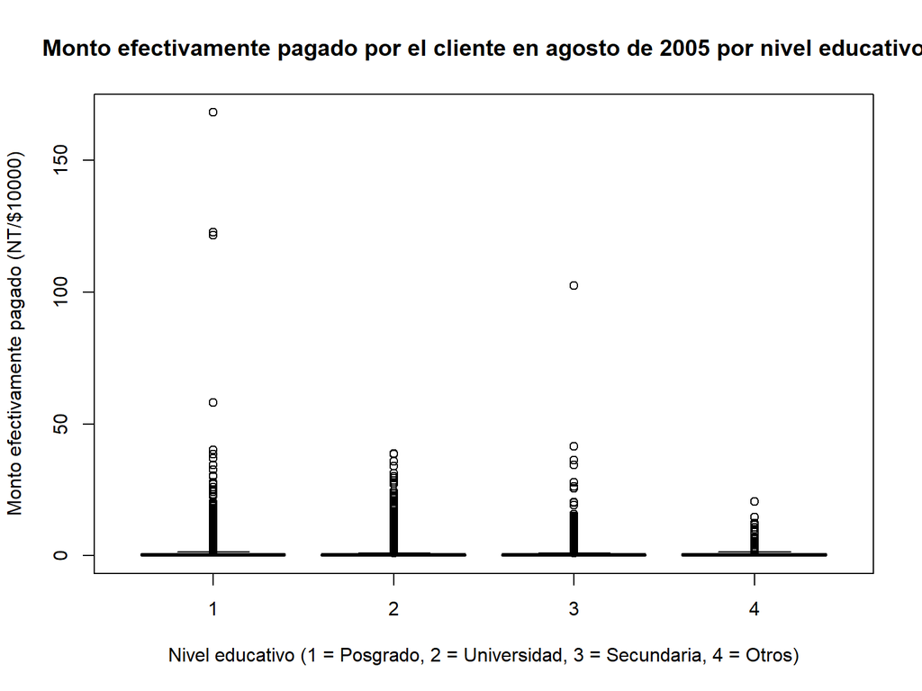

```r
boxplot(PAY_AMT2/10000 ~ EDUCATION, data = datos_credit_visu,
        main = "Monto efectivamente pagado por el cliente en agosto de 2005 por nivel educativo",
        xlab = "Nivel educativo (1 = Posgrado, 2 = Universidad, 3 = Secundaria, 4 = Otros)", ylab = "Monto efectivamente pagado (NT/$10000)",
        col = "grey90")
```

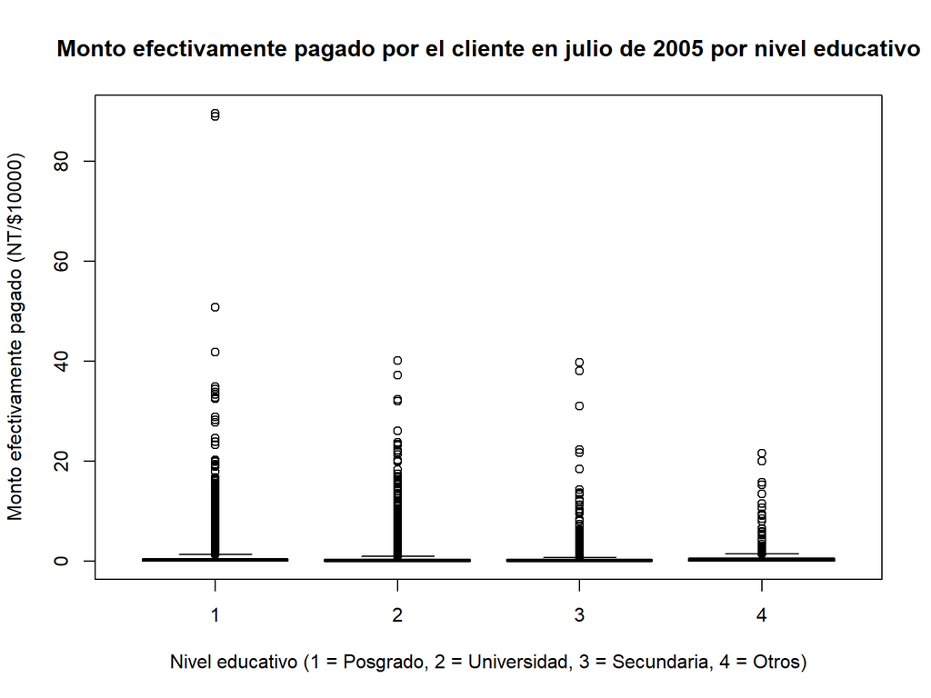

```r
boxplot(PAY_AMT3/10000 ~ EDUCATION, data = datos_credit_visu,
        main = "Monto efectivamente pagado por el cliente en julio de 2005 por nivel educativo",
        xlab = "Nivel educativo (1 = Posgrado, 2 = Universidad, 3 = Secundaria, 4 = Otros)", ylab = "Monto efectivamente pagado (NT/$10000)",
        col = "grey90")
```

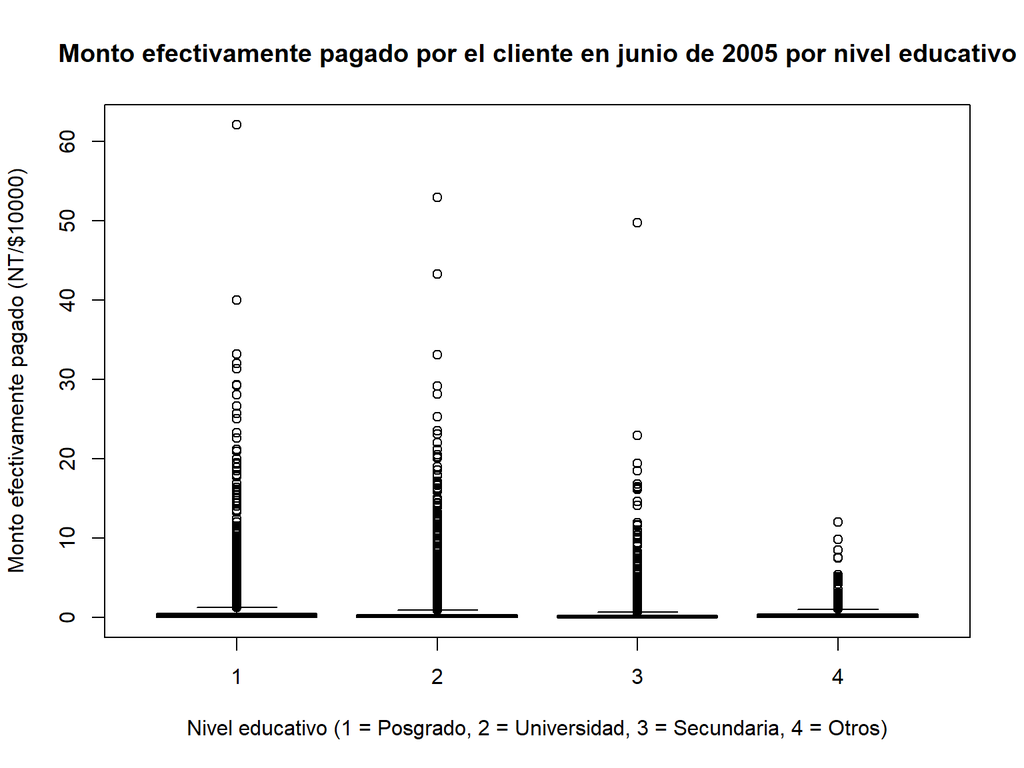

```r
boxplot(PAY_AMT4/10000 ~ EDUCATION, data = datos_credit_visu,
        main = "Monto efectivamente pagado por el cliente en junio de 2005 por nivel educativo",
        xlab = "Nivel educativo (1 = Posgrado, 2 = Universidad, 3 = Secundaria, 4 = Otros)", ylab = "Monto efectivamente pagado (NT/$10000)",
        col = "grey90")
```

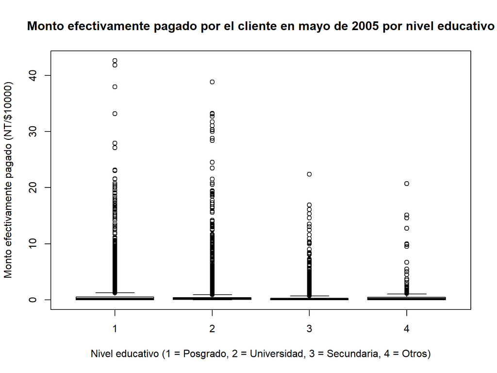

```r
boxplot(PAY_AMT5/10000 ~ EDUCATION, data = datos_credit_visu,
        main = "Monto efectivamente pagado por el cliente en mayo de 2005 por nivel educativo",
        xlab = "Nivel educativo (1 = Posgrado, 2 = Universidad, 3 = Secundaria, 4 = Otros)", ylab = "Monto efectivamente pagado (NT/$10000)",
        col = "grey90")
```

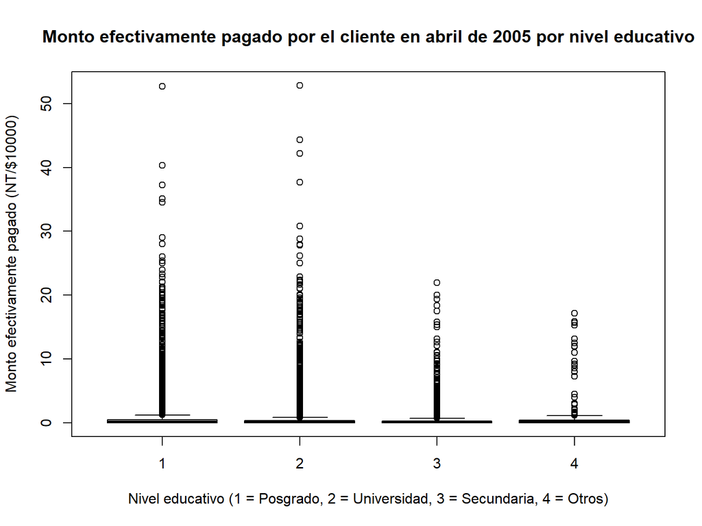

```r
boxplot(PAY_AMT6/10000 ~ EDUCATION, data = datos_credit_visu,
        main = "Monto efectivamente pagado por el cliente en abril de 2005 por nivel educativo",
        xlab = "Nivel educativo (1 = Posgrado, 2 = Universidad, 3 = Secundaria, 4 = Otros)", ylab = "Monto efectivamente pagado (NT/$10000)",
        col = "grey90")
```

**Finalmente, se concluye que el nivel educativo discrimina el cupo otorgado y la edad, pero no el saldo ni el pago.**

## 2.4 De “MARRIAGE”

En esta sección se cruza la variable categórica `MARRIAGE` (estado civil del cliente, convertida a factor) contra las mismas variables numéricas, para explorar si el estado civil se asocia con diferencias en el crédito otorgado, la edad, los montos de estado de cuenta y los montos pagados.

Se cruza `LIMIT_BAL` contra `MARRIAGE`, para comparar el monto de crédito otorgado según el estado civil del cliente.

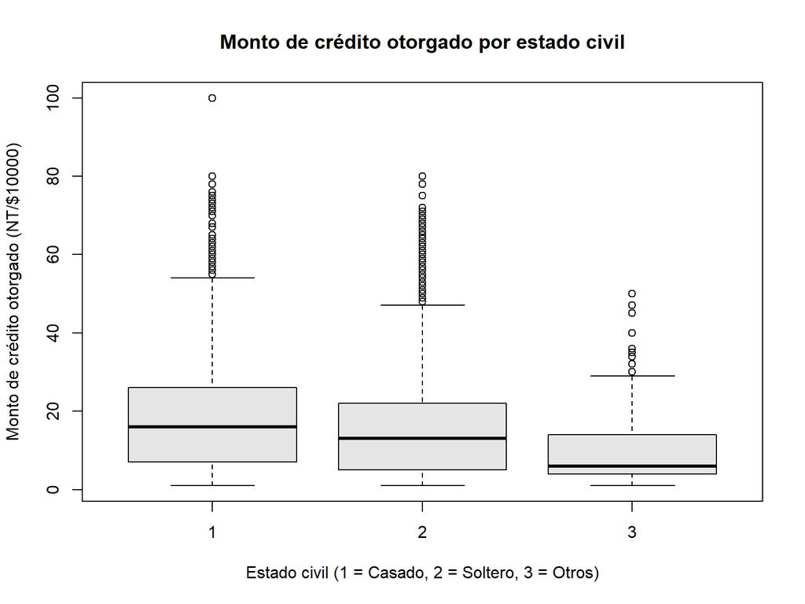

```r
boxplot(LIMIT_BAL/10000 ~ MARRIAGE, data = datos_credit_visu,
        main = "Monto de crédito otorgado por estado civil",
        xlab = "Estado civil (1 = Casado, 2 = Soltero, 3 = Otros)", ylab = "Monto de crédito otorgado (NT/$10000)",
        col = "grey90")
```

Se cruza `AGE` contra `MARRIAGE`, para observar la distribución de edades según el estado civil.

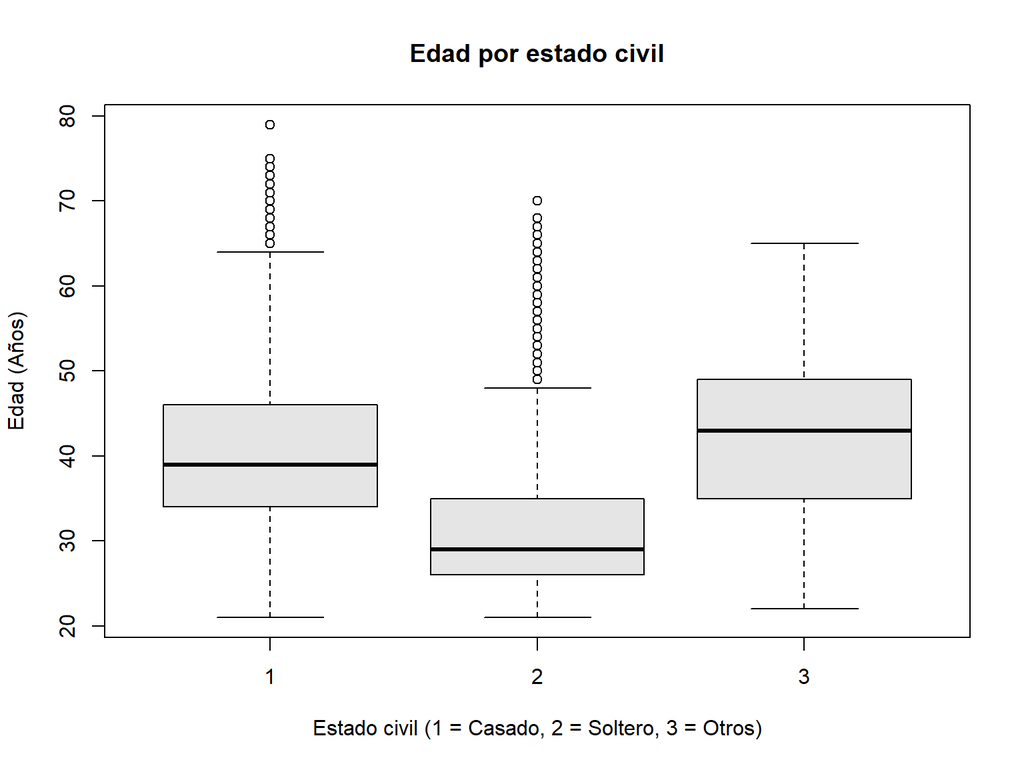

```r
boxplot(AGE ~ MARRIAGE, data = datos_credit_visu,
        main = "Edad por estado civil",
        xlab = "Estado civil (1 = Casado, 2 = Soltero, 3 = Otros)", ylab = "Edad (Años)",
        col = "grey90")
```

Se cruzan `BILL_AMT1` a `BILL_AMT6` contra `MARRIAGE`, generando un boxplot por mes para comparar el monto del estado de cuenta según el estado civil del cliente.

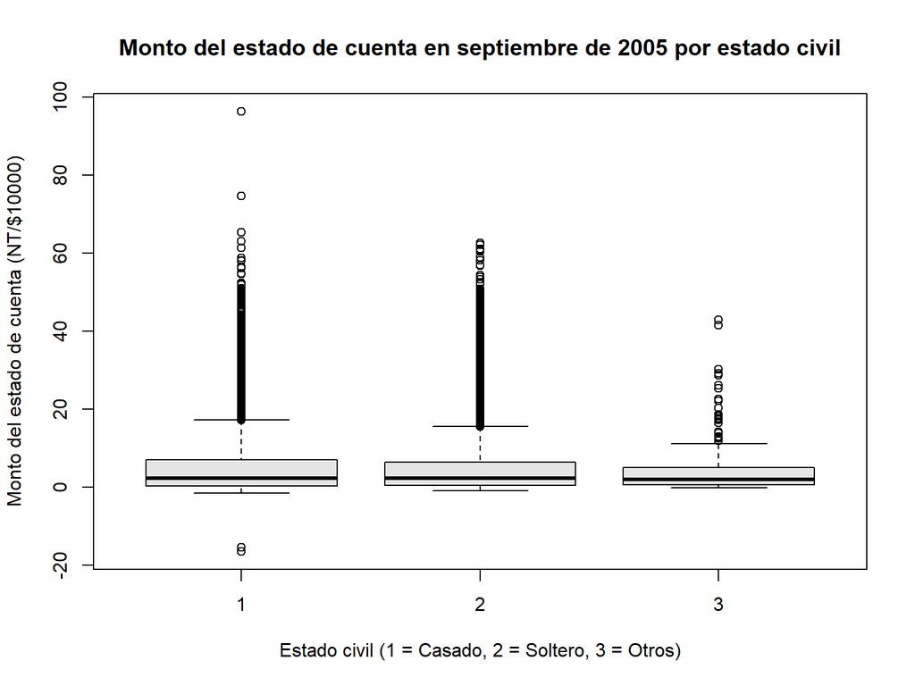

```r
boxplot(BILL_AMT1/10000 ~ MARRIAGE, data = datos_credit_visu,
        main = "Monto del estado de cuenta en septiembre de 2005 por estado civil",
        xlab = "Estado civil (1 = Casado, 2 = Soltero, 3 = Otros)", ylab = "Monto del estado de cuenta (NT/$10000)",
        col = "grey90")
```

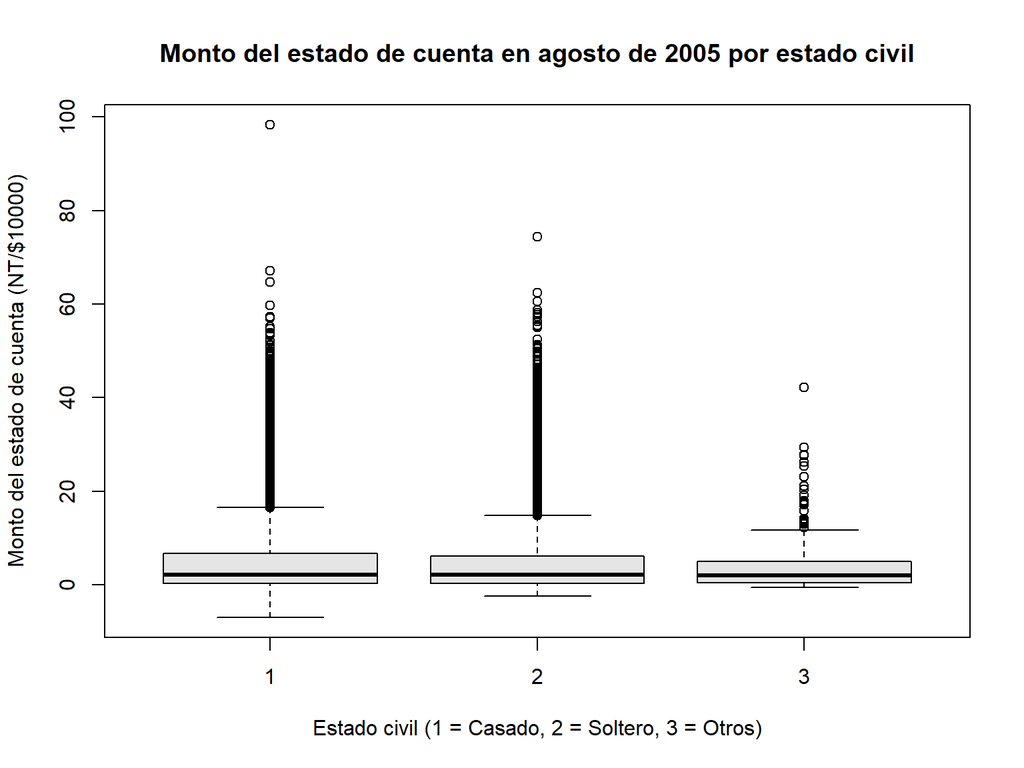

```r
boxplot(BILL_AMT2/10000 ~ MARRIAGE, data = datos_credit_visu,
        main = "Monto del estado de cuenta en agosto de 2005 por estado civil",
        xlab = "Estado civil (1 = Casado, 2 = Soltero, 3 = Otros)", ylab = "Monto del estado de cuenta (NT/$10000)",
        col = "grey90")
```

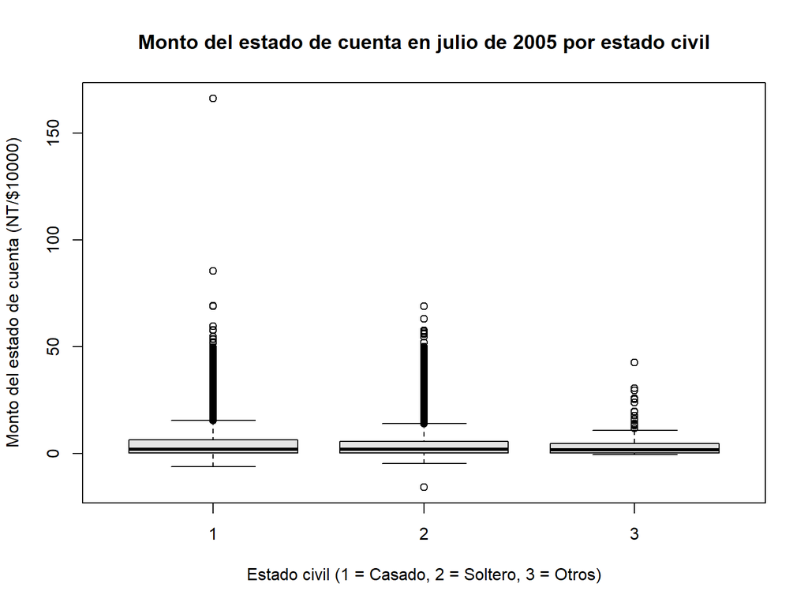

```r
boxplot(BILL_AMT3/10000 ~ MARRIAGE, data = datos_credit_visu,
        main = "Monto del estado de cuenta en julio de 2005 por estado civil",
        xlab = "Estado civil (1 = Casado, 2 = Soltero, 3 = Otros)", ylab = "Monto del estado de cuenta (NT/$10000)",
        col = "grey90")
```

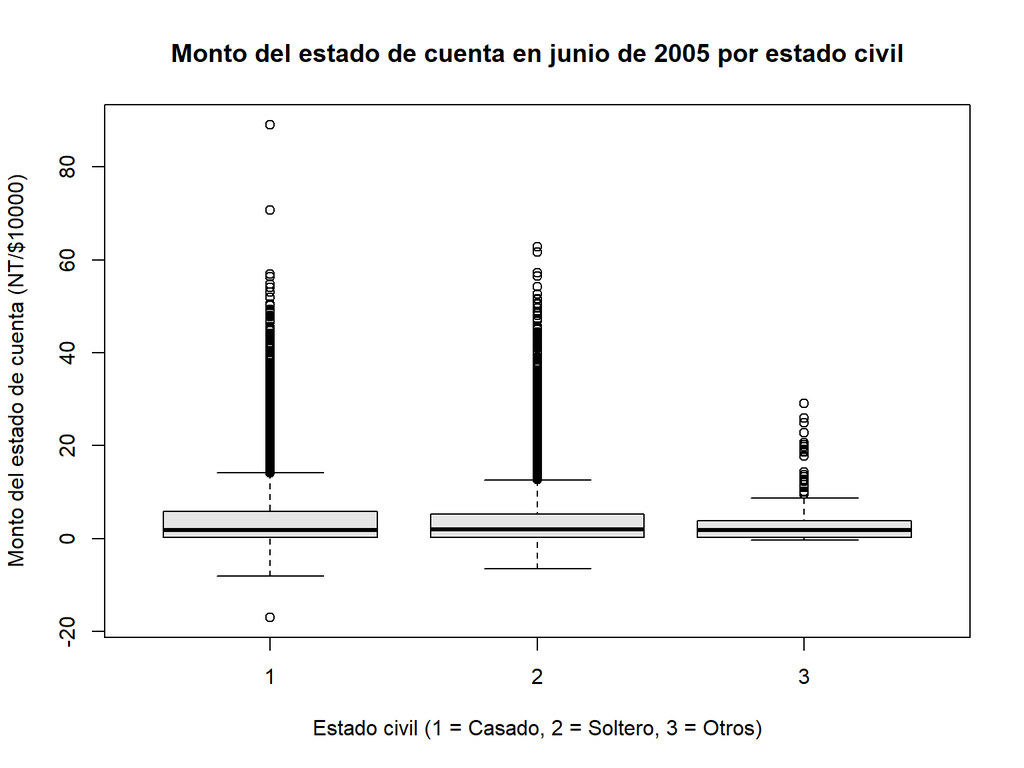

```r
boxplot(BILL_AMT4/10000 ~ MARRIAGE, data = datos_credit_visu,
        main = "Monto del estado de cuenta en junio de 2005 por estado civil",
        xlab = "Estado civil (1 = Casado, 2 = Soltero, 3 = Otros)", ylab = "Monto del estado de cuenta (NT/$10000)",
        col = "grey90")
```

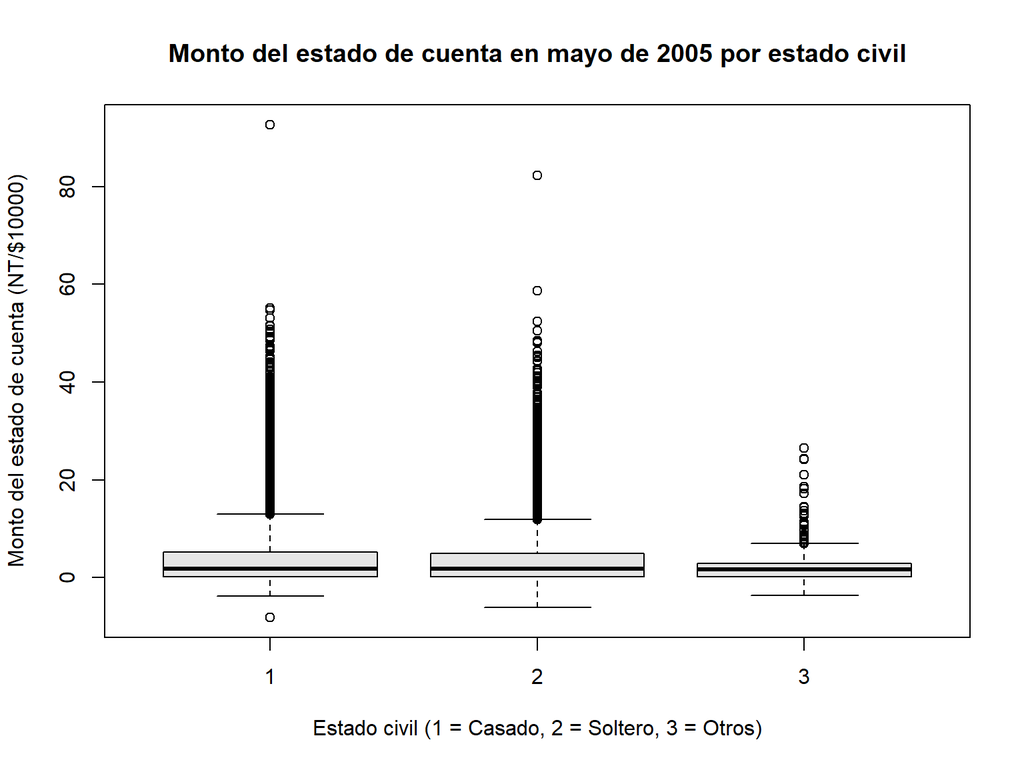

```r
boxplot(BILL_AMT5/10000 ~ MARRIAGE, data = datos_credit_visu,
        main = "Monto del estado de cuenta en mayo de 2005 por estado civil",
        xlab = "Estado civil (1 = Casado, 2 = Soltero, 3 = Otros)", ylab = "Monto del estado de cuenta (NT/$10000)",
        col = "grey90")
```

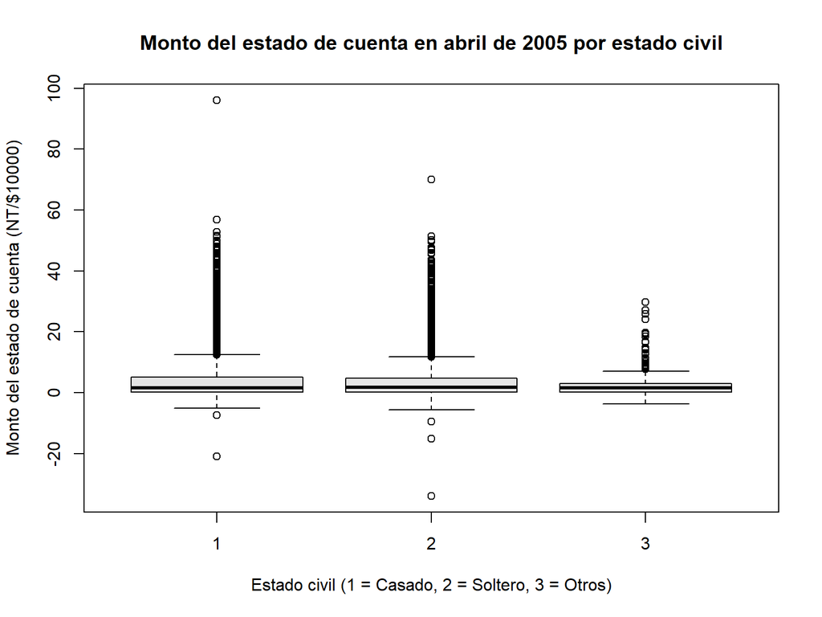

```r
boxplot(BILL_AMT6/10000 ~ MARRIAGE, data = datos_credit_visu,
        main = "Monto del estado de cuenta en abril de 2005 por estado civil",
        xlab = "Estado civil (1 = Casado, 2 = Soltero, 3 = Otros)", ylab = "Monto del estado de cuenta (NT/$10000)",
        col = "grey90")
```

Se cruzan `PAY_AMT1` a `PAY_AMT6` contra `MARRIAGE`, para comparar cuánto pagaron efectivamente los clientes según su estado civil, mes a mes.

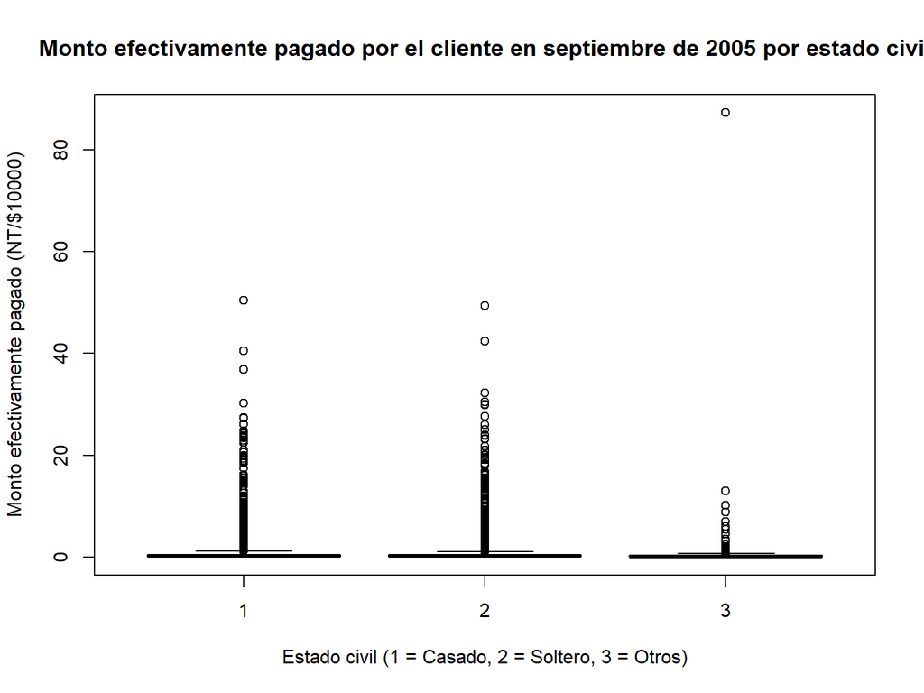

```r
boxplot(PAY_AMT1/10000 ~ MARRIAGE, data = datos_credit_visu,
        main = "Monto efectivamente pagado por el cliente en septiembre de 2005 por estado civil",
        xlab = "Estado civil (1 = Casado, 2 = Soltero, 3 = Otros)", ylab = "Monto efectivamente pagado (NT/$10000)",
        col = "grey90")
```

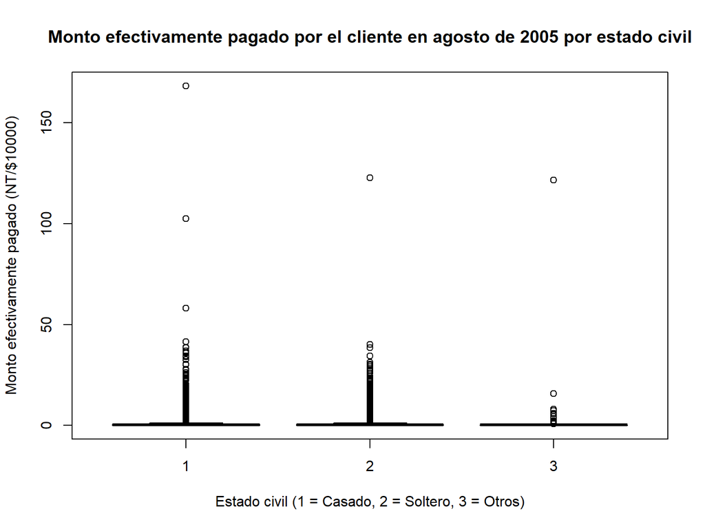

```r
boxplot(PAY_AMT2/10000 ~ MARRIAGE, data = datos_credit_visu,
        main = "Monto efectivamente pagado por el cliente en agosto de 2005 por estado civil",
        xlab = "Estado civil (1 = Casado, 2 = Soltero, 3 = Otros)", ylab = "Monto efectivamente pagado (NT/$10000)",
        col = "grey90")
```

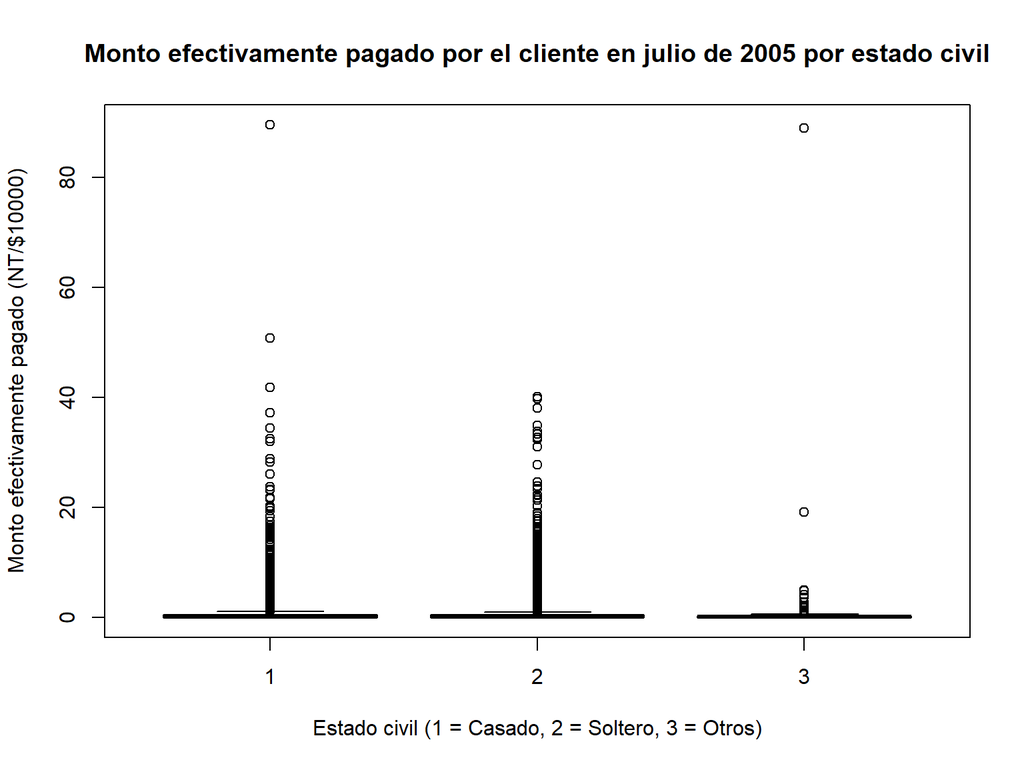

```r
boxplot(PAY_AMT3/10000 ~ MARRIAGE, data = datos_credit_visu,
        main = "Monto efectivamente pagado por el cliente en julio de 2005 por estado civil",
        xlab = "Estado civil (1 = Casado, 2 = Soltero, 3 = Otros)", ylab = "Monto efectivamente pagado (NT/$10000)",
        col = "grey90")
```

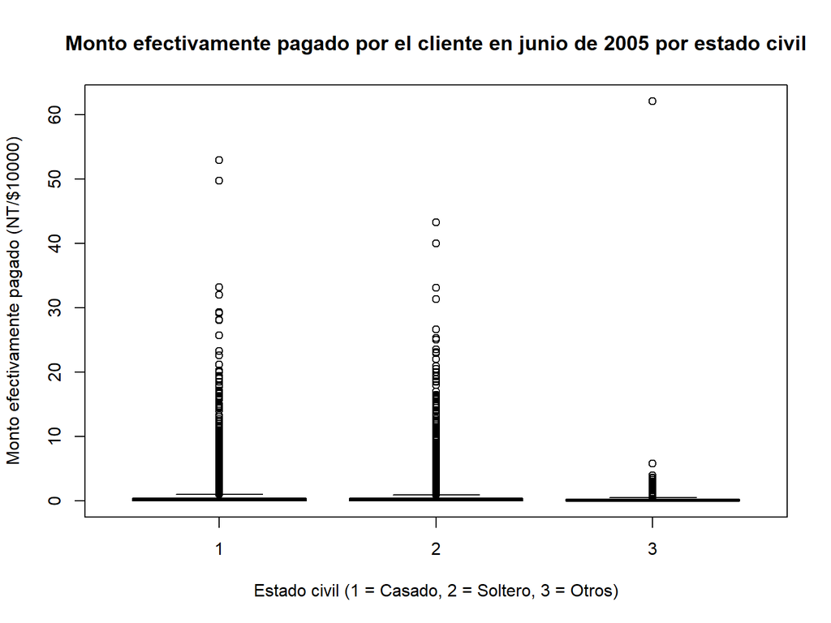

```r
boxplot(PAY_AMT4/10000 ~ MARRIAGE, data = datos_credit_visu,
        main = "Monto efectivamente pagado por el cliente en junio de 2005 por estado civil",
        xlab = "Estado civil (1 = Casado, 2 = Soltero, 3 = Otros)", ylab = "Monto efectivamente pagado (NT/$10000)",
        col = "grey90")
```

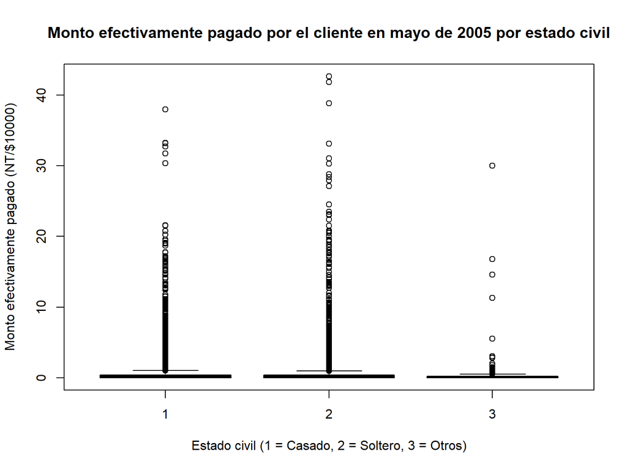

```r
boxplot(PAY_AMT5/10000 ~ MARRIAGE, data = datos_credit_visu,
        main = "Monto efectivamente pagado por el cliente en mayo de 2005 por estado civil",
        xlab = "Estado civil (1 = Casado, 2 = Soltero, 3 = Otros)", ylab = "Monto efectivamente pagado (NT/$10000)",
        col = "grey90")
```

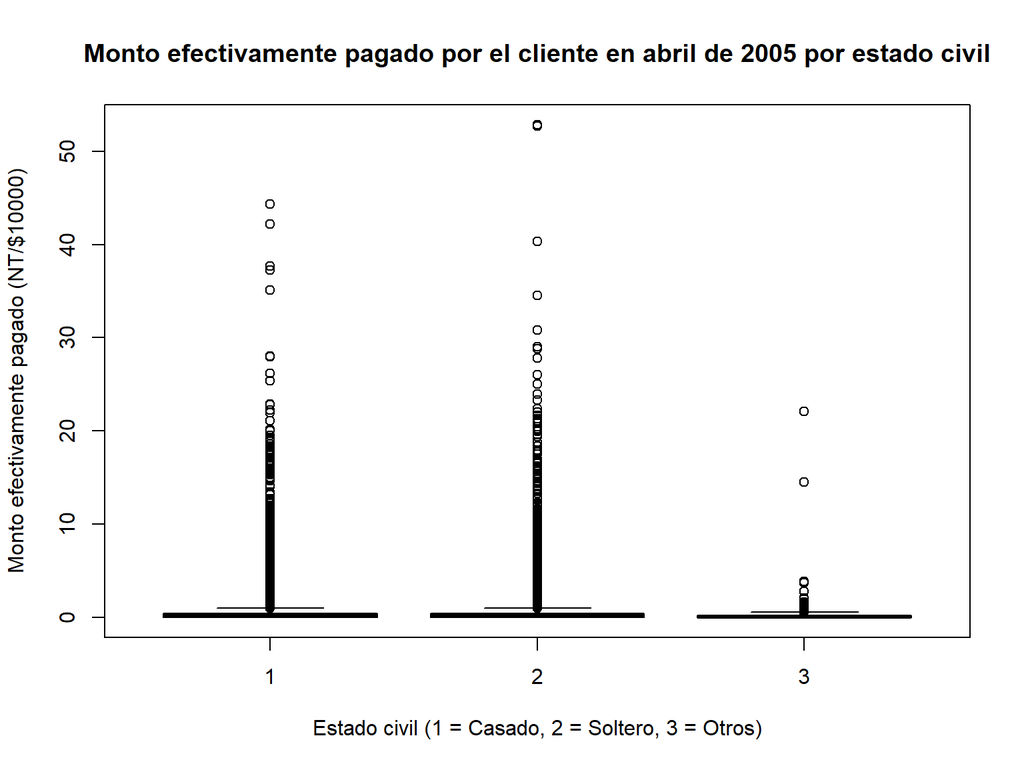

```r
boxplot(PAY_AMT6/10000 ~ MARRIAGE, data = datos_credit_visu,
        main = "Monto efectivamente pagado por el cliente en abril de 2005 por estado civil",
        xlab = "Estado civil (1 = Casado, 2 = Soltero, 3 = Otros)", ylab = "Monto efectivamente pagado (NT/$10000)",
        col = "grey90")
```

## 2.5 De “default payment next month”

En esta sección se cruza la variable de respuesta `default payment next month` (indicador de si el cliente incurrió en impago al mes siguiente, convertida a factor) contra las mismas variables numéricas. Esta es la sección más importante desde el punto de vista analítico, ya que permite explorar visualmente qué variables podrían estar asociadas con el impago, lo cual es relevante de cara a un eventual modelo predictivo.

Se cruza `LIMIT_BAL` contra `default payment next month`, para observar si los clientes que incurren en impago tienden a tener montos de crédito otorgado distintos a los que no incurren.

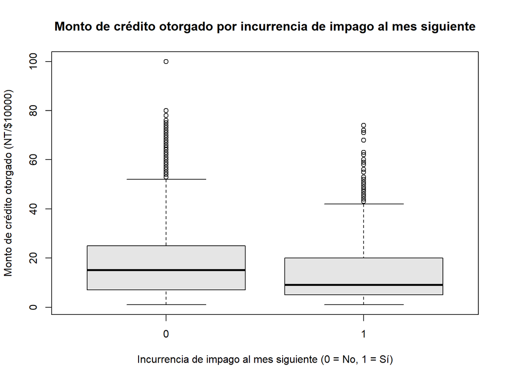

```r
boxplot(LIMIT_BAL/10000 ~ `default payment next month`, data = datos_credit_visu,
        main = "Monto de crédito otorgado por incurrencia de impago al mes siguiente",
        xlab = "Incurrencia de impago al mes siguiente (0 = No, 1 = Sí)", ylab = "Monto de crédito otorgado (NT/$10000)",
        col = "grey90")
```

Se cruza `AGE` contra `default payment next month`, para observar si la edad se relaciona con la incurrencia en impago.

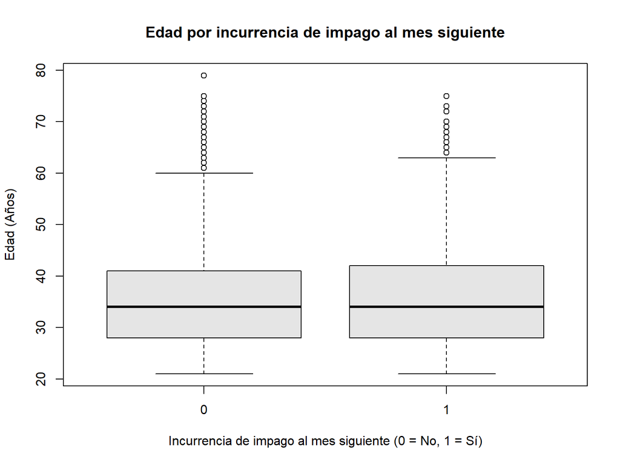

```r
boxplot(AGE ~ `default payment next month`, data = datos_credit_visu,
        main = "Edad por incurrencia de impago al mes siguiente",
        xlab = "Incurrencia de impago al mes siguiente (0 = No, 1 = Sí)", ylab = "Edad (Años)",
        col = "grey90")
```

Se cruzan `BILL_AMT1` a `BILL_AMT6` contra `default payment next month`, generando un boxplot por mes para comparar el monto del estado de cuenta entre quienes incurrieron en impago y quienes no.

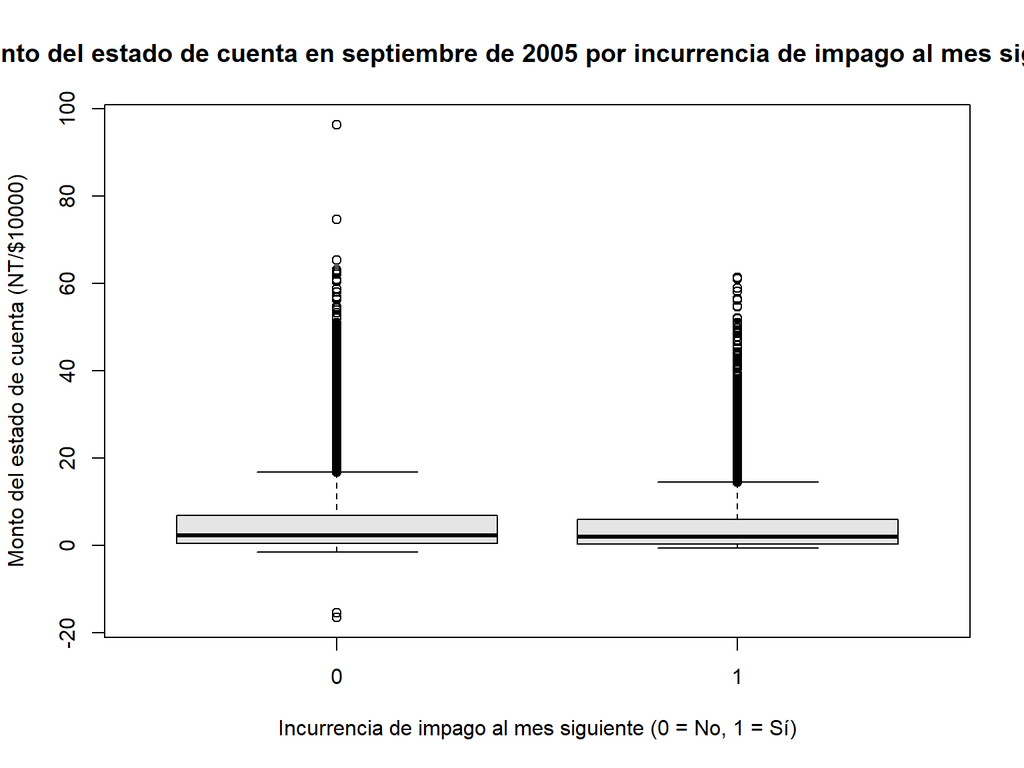

```r
boxplot(BILL_AMT1/10000 ~ `default payment next month`, data = datos_credit_visu,
        main = "Monto del estado de cuenta en septiembre de 2005 por incurrencia de impago al mes siguiente",
        xlab = "Incurrencia de impago al mes siguiente (0 = No, 1 = Sí)", ylab = "Monto del estado de cuenta (NT/$10000)",
        col = "grey90")
```

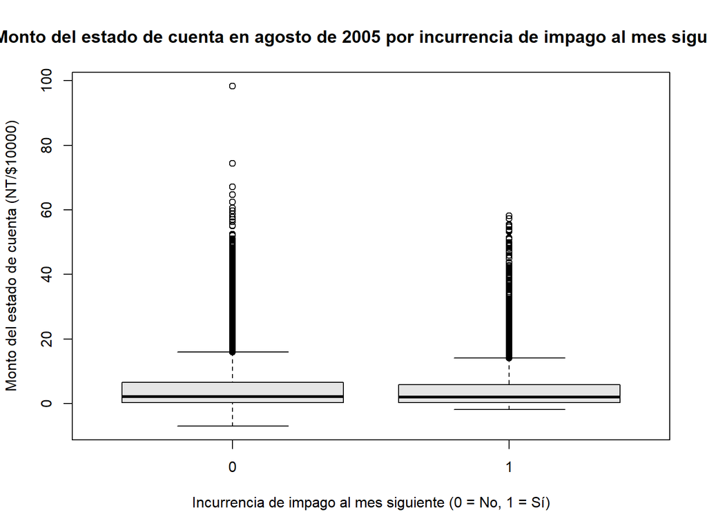

```r
boxplot(BILL_AMT2/10000 ~ `default payment next month`, data = datos_credit_visu,
        main = "Monto del estado de cuenta en agosto de 2005 por incurrencia de impago al mes siguiente",
        xlab = "Incurrencia de impago al mes siguiente (0 = No, 1 = Sí)", ylab = "Monto del estado de cuenta (NT/$10000)",
        col = "grey90")
```

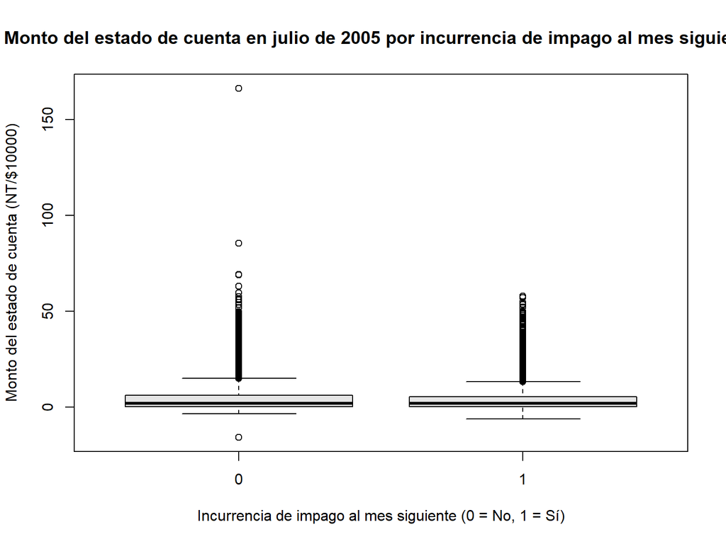

```r
boxplot(BILL_AMT3/10000 ~ `default payment next month`, data = datos_credit_visu,
        main = "Monto del estado de cuenta en julio de 2005 por incurrencia de impago al mes siguiente",
        xlab = "Incurrencia de impago al mes siguiente (0 = No, 1 = Sí)", ylab = "Monto del estado de cuenta (NT/$10000)",
        col = "grey90")
```

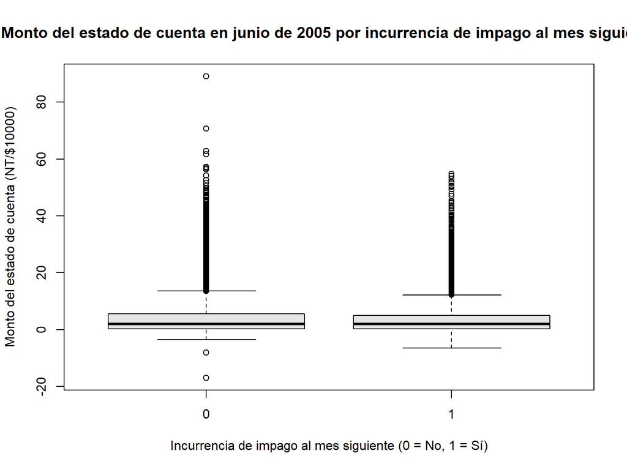

```r
boxplot(BILL_AMT4/10000 ~ `default payment next month`, data = datos_credit_visu,
        main = "Monto del estado de cuenta en junio de 2005 por incurrencia de impago al mes siguiente",
        xlab = "Incurrencia de impago al mes siguiente (0 = No, 1 = Sí)", ylab = "Monto del estado de cuenta (NT/$10000)",
        col = "grey90")
```

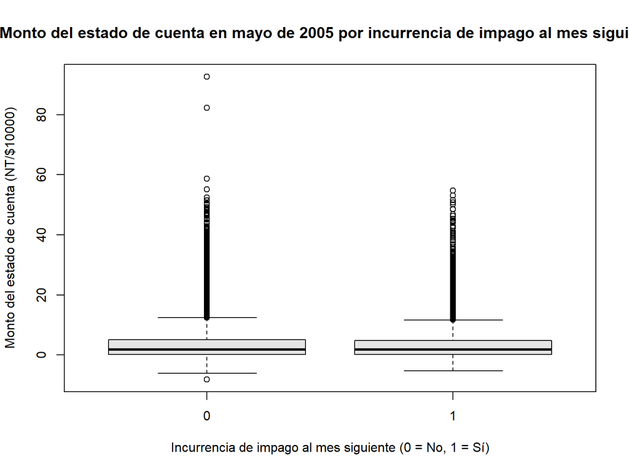

```r
boxplot(BILL_AMT5/10000 ~ `default payment next month`, data = datos_credit_visu,
        main = "Monto del estado de cuenta en mayo de 2005 por incurrencia de impago al mes siguiente",
        xlab = "Incurrencia de impago al mes siguiente (0 = No, 1 = Sí)", ylab = "Monto del estado de cuenta (NT/$10000)",
        col = "grey90")
```

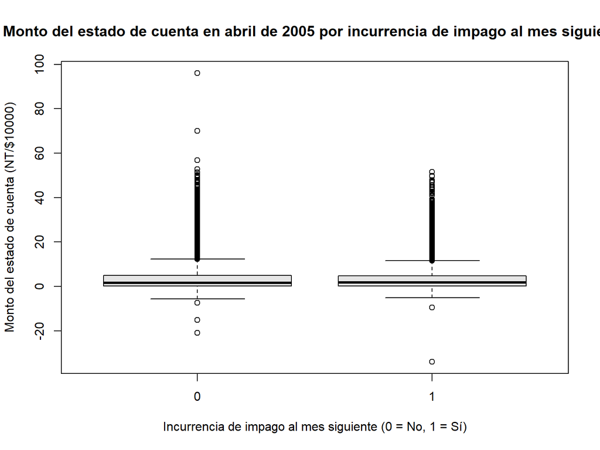

```r
boxplot(BILL_AMT6/10000 ~ `default payment next month`, data = datos_credit_visu,
        main = "Monto del estado de cuenta en abril de 2005 por incurrencia de impago al mes siguiente",
        xlab = "Incurrencia de impago al mes siguiente (0 = No, 1 = Sí)", ylab = "Monto del estado de cuenta (NT/$10000)",
        col = "grey90")
```

Se cruzan `PAY_AMT1` a `PAY_AMT6` contra `default payment next month`, para comparar cuánto pagaron efectivamente los clientes que incurrieron en impago frente a los que no, mes a mes.

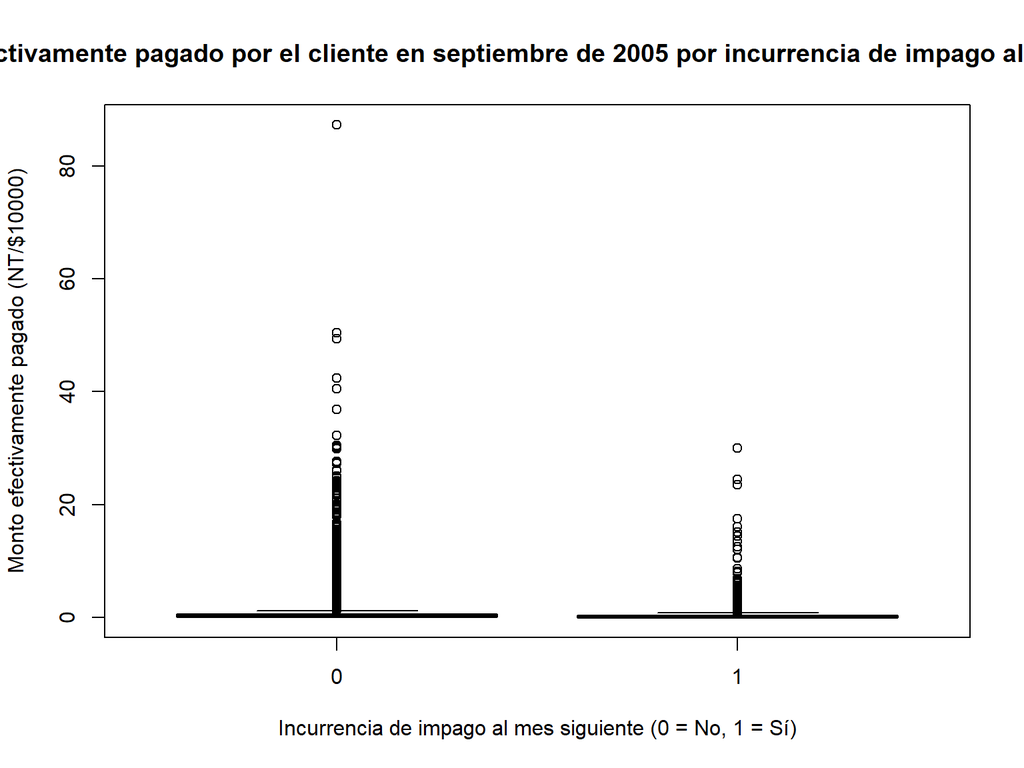

```r
boxplot(PAY_AMT1/10000 ~ `default payment next month`, data = datos_credit_visu,
        main = "Monto efectivamente pagado por el cliente en septiembre de 2005 por incurrencia de impago al mes siguiente",
        xlab = "Incurrencia de impago al mes siguiente (0 = No, 1 = Sí)", ylab = "Monto efectivamente pagado (NT/$10000)",
        col = "grey90")
```

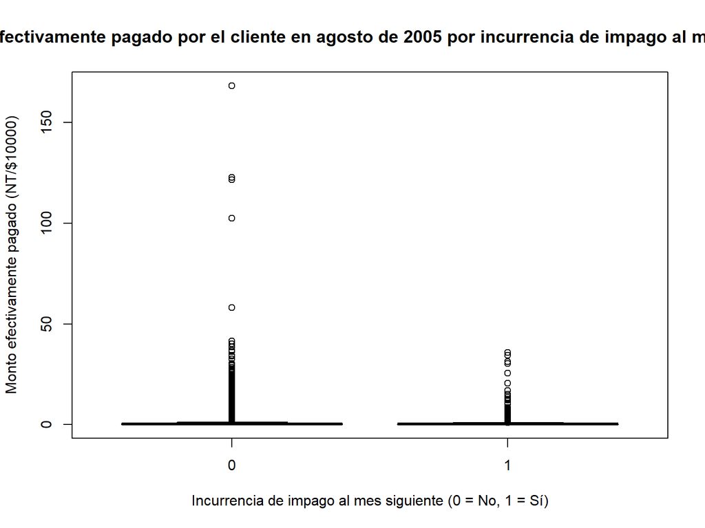

```r
boxplot(PAY_AMT2/10000 ~ `default payment next month`, data = datos_credit_visu,
        main = "Monto efectivamente pagado por el cliente en agosto de 2005 por incurrencia de impago al mes siguiente",
        xlab = "Incurrencia de impago al mes siguiente (0 = No, 1 = Sí)", ylab = "Monto efectivamente pagado (NT/$10000)",
        col = "grey90")
```

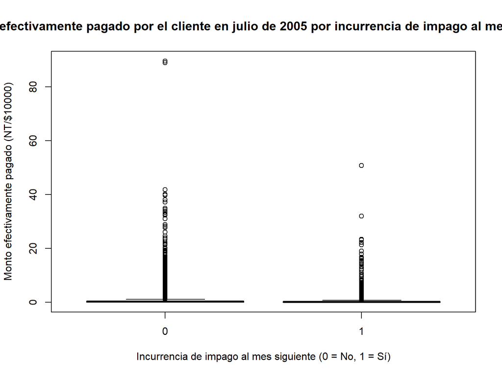

```r
boxplot(PAY_AMT3/10000 ~ `default payment next month`, data = datos_credit_visu,
        main = "Monto efectivamente pagado por el cliente en julio de 2005 por incurrencia de impago al mes siguiente",
        xlab = "Incurrencia de impago al mes siguiente (0 = No, 1 = Sí)", ylab = "Monto efectivamente pagado (NT/$10000)",
        col = "grey90")
```

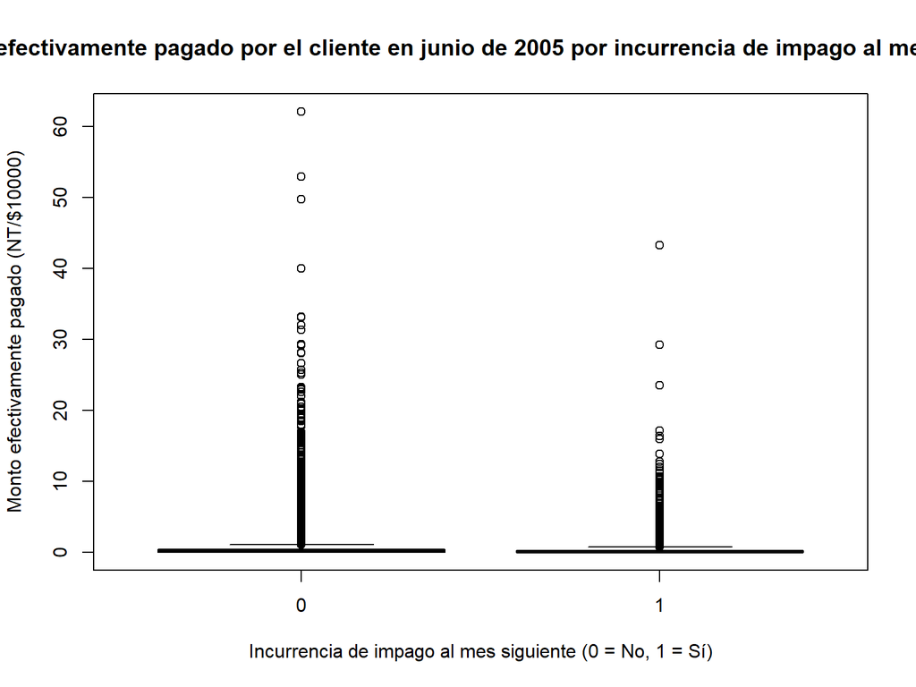

```r
boxplot(PAY_AMT4/10000 ~ `default payment next month`, data = datos_credit_visu,
        main = "Monto efectivamente pagado por el cliente en junio de 2005 por incurrencia de impago al mes siguiente",
        xlab = "Incurrencia de impago al mes siguiente (0 = No, 1 = Sí)", ylab = "Monto efectivamente pagado (NT/$10000)",
        col = "grey90")
```

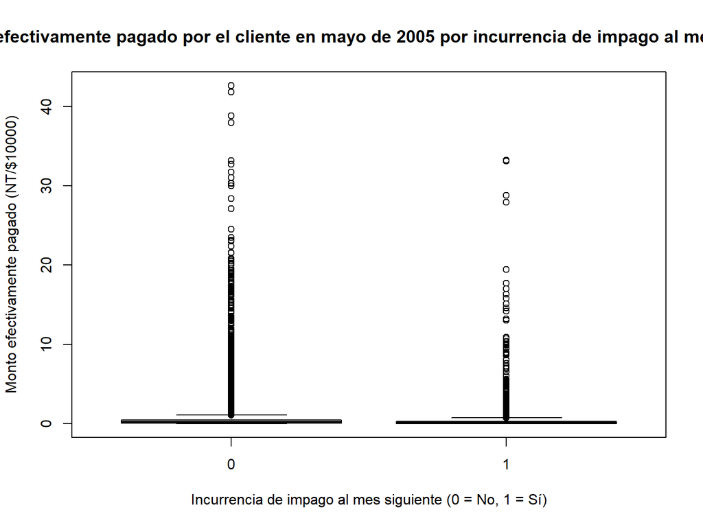

```r
boxplot(PAY_AMT5/10000 ~ `default payment next month`, data = datos_credit_visu,
        main = "Monto efectivamente pagado por el cliente en mayo de 2005 por incurrencia de impago al mes siguiente",
        xlab = "Incurrencia de impago al mes siguiente (0 = No, 1 = Sí)", ylab = "Monto efectivamente pagado (NT/$10000)",
        col = "grey90")
```

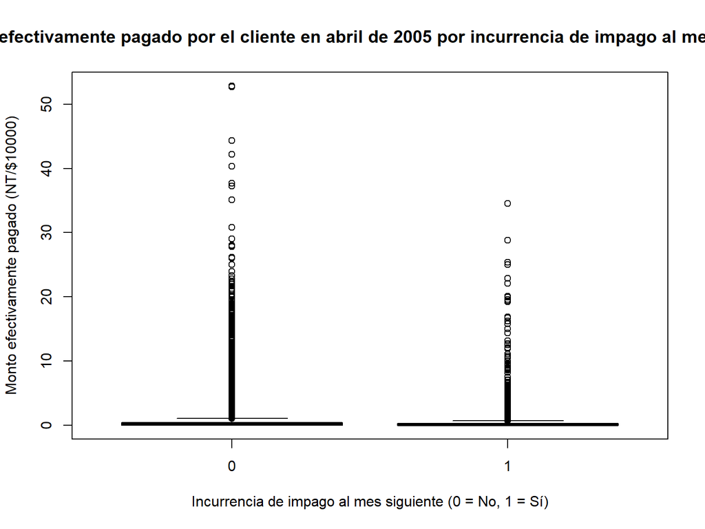

```r
boxplot(PAY_AMT6/10000 ~ `default payment next month`, data = datos_credit_visu,
        main = "Monto efectivamente pagado por el cliente en abril de 2005 por incurrencia de impago al mes siguiente",
        xlab = "Incurrencia de impago al mes siguiente (0 = No, 1 = Sí)", ylab = "Monto efectivamente pagado (NT/$10000)",
        col = "grey90")
```

## 2.6 De PAY_0

En esta sección se cruza `PAY_0` (estado de pago del cliente en septiembre de 2005, convertida a factor) contra las mismas variables numéricas, para observar si el estado de pago más reciente se relaciona con el monto de crédito, la edad, los montos de estado de cuenta y los montos pagados.

Se cruza `LIMIT_BAL` contra `PAY_0`, para comparar el monto de crédito otorgado según el estado de pago de septiembre de 2005.

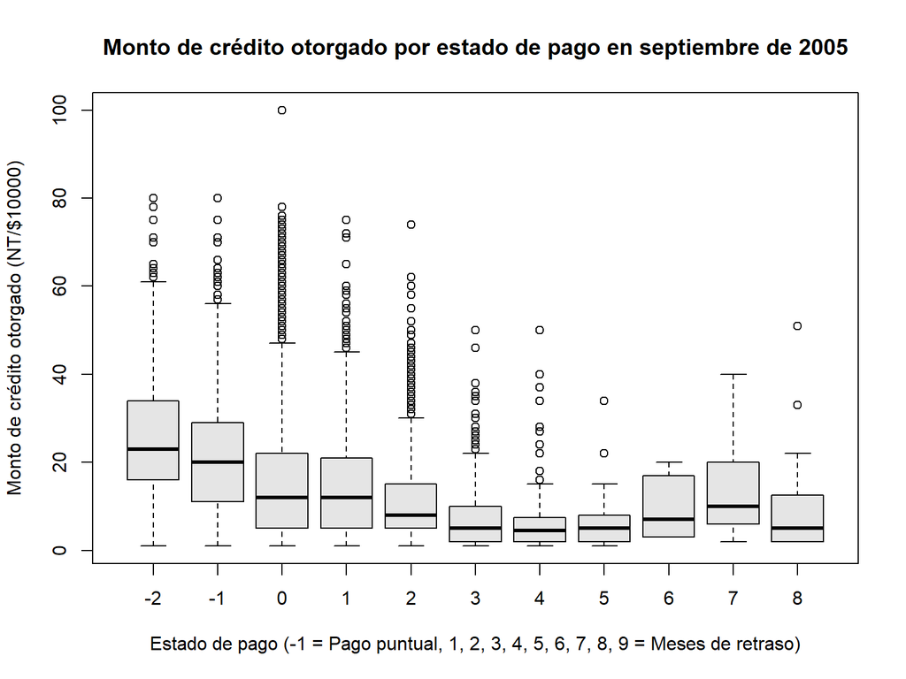

```r
boxplot(LIMIT_BAL/10000 ~ PAY_0, data = datos_credit_visu,
        main = "Monto de crédito otorgado por estado de pago en septiembre de 2005",
        xlab = "Estado de pago (-1 = Pago puntual, 1, 2, 3, 4, 5, 6, 7, 8, 9 = Meses de retraso)", ylab = "Monto de crédito otorgado (NT/$10000)",
        col = "grey90")
```

Se cruza `AGE` contra `PAY_0`, para observar si la edad se relaciona con el estado de pago de septiembre de 2005.

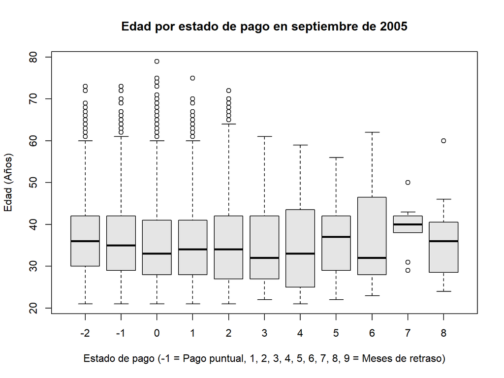

```r
boxplot(AGE ~ PAY_0, data = datos_credit_visu,
        main = "Edad por estado de pago en septiembre de 2005",
        xlab = "Estado de pago (-1 = Pago puntual, 1, 2, 3, 4, 5, 6, 7, 8, 9 = Meses de retraso)", ylab = "Edad (Años)",
        col = "grey90")
```

Se cruzan `BILL_AMT1` a `BILL_AMT6` contra `PAY_0`, generando un boxplot por mes para comparar el monto del estado de cuenta según el estado de pago de septiembre de 2005.

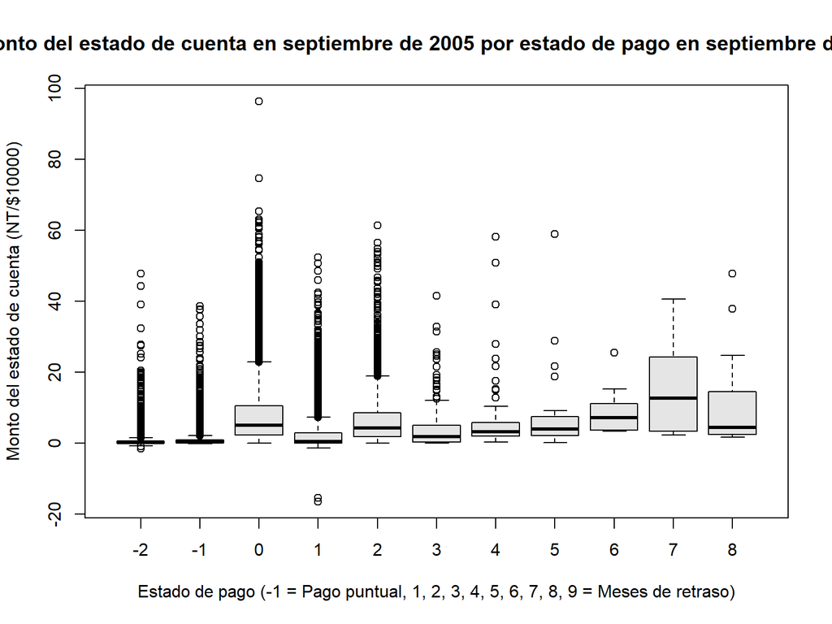

```r
boxplot(BILL_AMT1/10000 ~ PAY_0, data = datos_credit_visu,
        main = "Monto del estado de cuenta en septiembre de 2005 por estado de pago en septiembre de 2005",
        xlab = "Estado de pago (-1 = Pago puntual, 1, 2, 3, 4, 5, 6, 7, 8, 9 = Meses de retraso)", ylab = "Monto del estado de cuenta (NT/$10000)",
        col = "grey90")
```

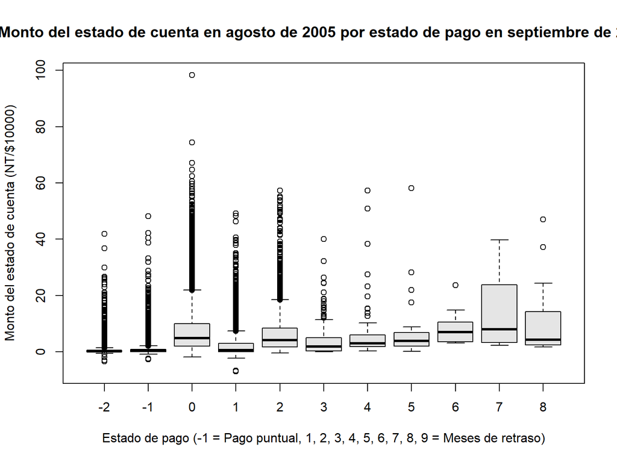

```r
boxplot(BILL_AMT2/10000 ~ PAY_0, data = datos_credit_visu,
        main = "Monto del estado de cuenta en agosto de 2005 por estado de pago en septiembre de 2005",
        xlab = "Estado de pago (-1 = Pago puntual, 1, 2, 3, 4, 5, 6, 7, 8, 9 = Meses de retraso)", ylab = "Monto del estado de cuenta (NT/$10000)",
        col = "grey90")
```

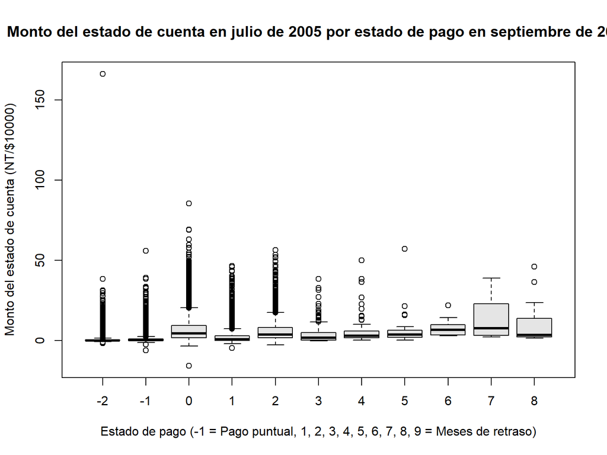

```r
boxplot(BILL_AMT3/10000 ~ PAY_0, data = datos_credit_visu,
        main = "Monto del estado de cuenta en julio de 2005 por estado de pago en septiembre de 2005",
        xlab = "Estado de pago (-1 = Pago puntual, 1, 2, 3, 4, 5, 6, 7, 8, 9 = Meses de retraso)", ylab = "Monto del estado de cuenta (NT/$10000)",
        col = "grey90")
```

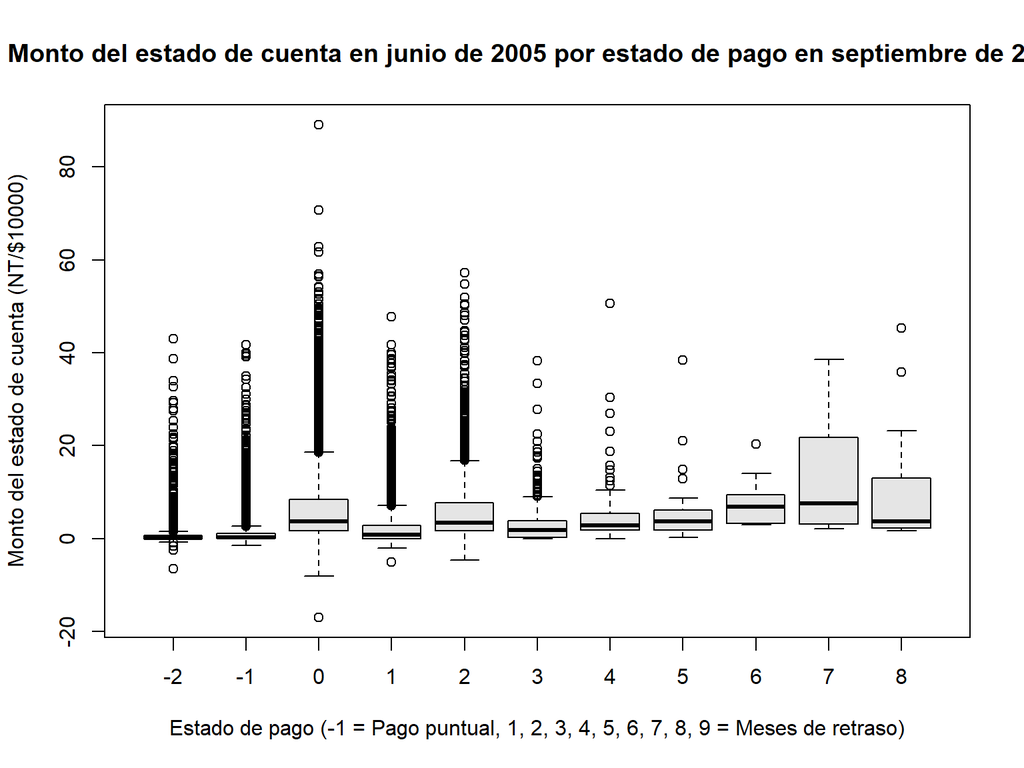

```r
boxplot(BILL_AMT4/10000 ~ PAY_0, data = datos_credit_visu,
        main = "Monto del estado de cuenta en junio de 2005 por estado de pago en septiembre de 2005",
        xlab = "Estado de pago (-1 = Pago puntual, 1, 2, 3, 4, 5, 6, 7, 8, 9 = Meses de retraso)", ylab = "Monto del estado de cuenta (NT/$10000)",
        col = "grey90")
```

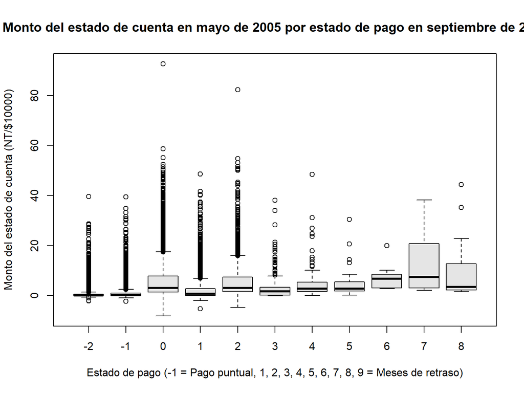

```r
boxplot(BILL_AMT5/10000 ~ PAY_0, data = datos_credit_visu,
        main = "Monto del estado de cuenta en mayo de 2005 por estado de pago en septiembre de 2005",
        xlab = "Estado de pago (-1 = Pago puntual, 1, 2, 3, 4, 5, 6, 7, 8, 9 = Meses de retraso)", ylab = "Monto del estado de cuenta (NT/$10000)",
        col = "grey90")
```

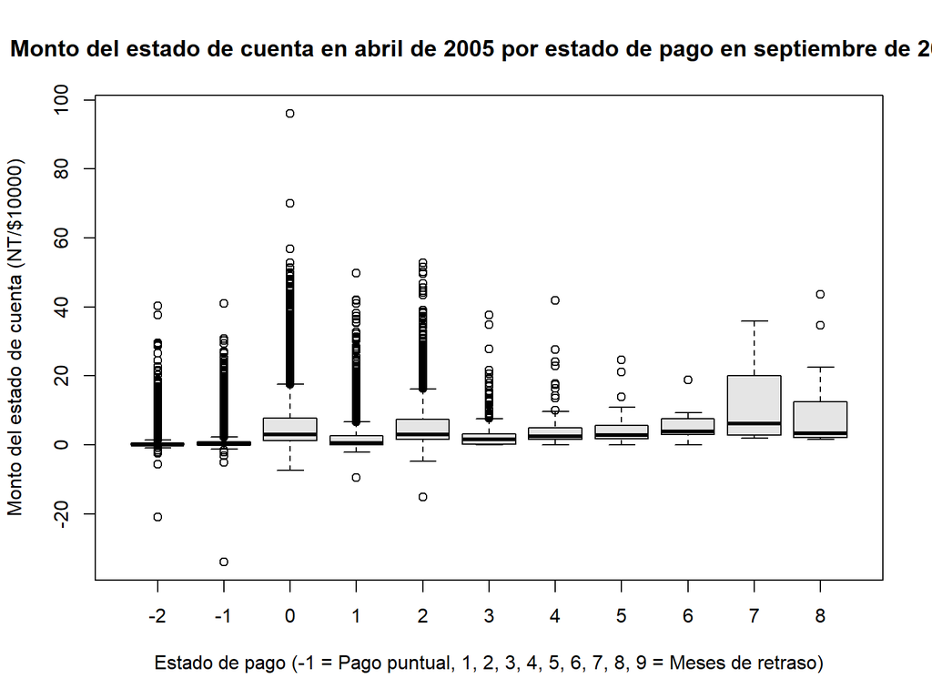

```r
boxplot(BILL_AMT6/10000 ~ PAY_0, data = datos_credit_visu,
        main = "Monto del estado de cuenta en abril de 2005 por estado de pago en septiembre de 2005",
        xlab = "Estado de pago (-1 = Pago puntual, 1, 2, 3, 4, 5, 6, 7, 8, 9 = Meses de retraso)", ylab = "Monto del estado de cuenta (NT/$10000)",
        col = "grey90")
```

Se cruzan `PAY_AMT1` a `PAY_AMT6` contra `PAY_0`, para comparar cuánto pagaron efectivamente los clientes según su estado de pago de septiembre de 2005, mes a mes.

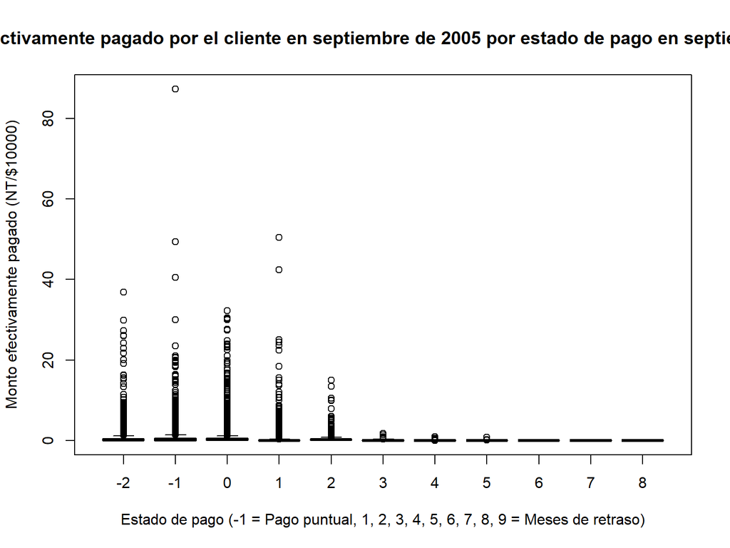

```r
boxplot(PAY_AMT1/10000 ~ PAY_0, data = datos_credit_visu,
        main = "Monto efectivamente pagado por el cliente en septiembre de 2005 por estado de pago en septiembre de 2005",
        xlab = "Estado de pago (-1 = Pago puntual, 1, 2, 3, 4, 5, 6, 7, 8, 9 = Meses de retraso)", ylab = "Monto efectivamente pagado (NT/$10000)",
        col = "grey90")
```

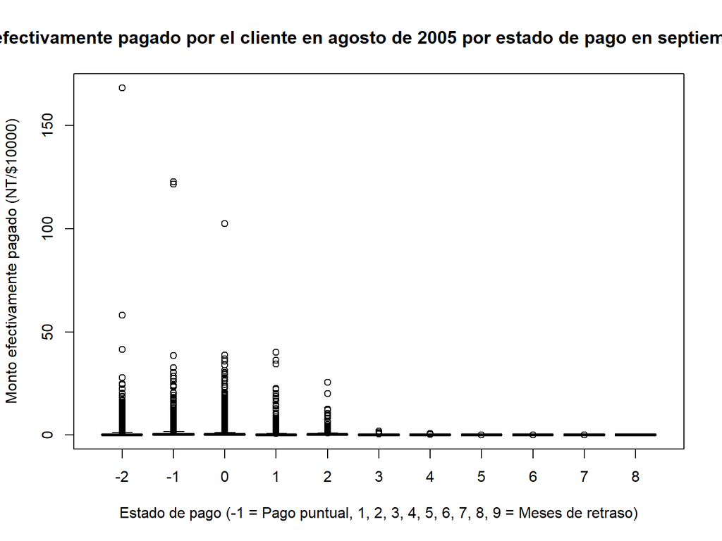

```r
boxplot(PAY_AMT2/10000 ~ PAY_0, data = datos_credit_visu,
        main = "Monto efectivamente pagado por el cliente en agosto de 2005 por estado de pago en septiembre de 2005",
        xlab = "Estado de pago (-1 = Pago puntual, 1, 2, 3, 4, 5, 6, 7, 8, 9 = Meses de retraso)", ylab = "Monto efectivamente pagado (NT/$10000)",
        col = "grey90")
```

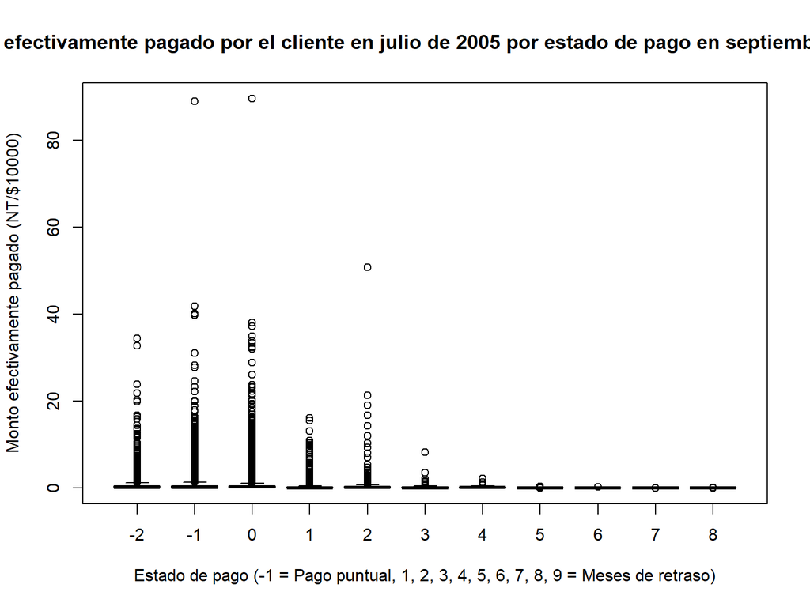

```r
boxplot(PAY_AMT3/10000 ~ PAY_0, data = datos_credit_visu,
        main = "Monto efectivamente pagado por el cliente en julio de 2005 por estado de pago en septiembre de 2005",
        xlab = "Estado de pago (-1 = Pago puntual, 1, 2, 3, 4, 5, 6, 7, 8, 9 = Meses de retraso)", ylab = "Monto efectivamente pagado (NT/$10000)",
        col = "grey90")
```

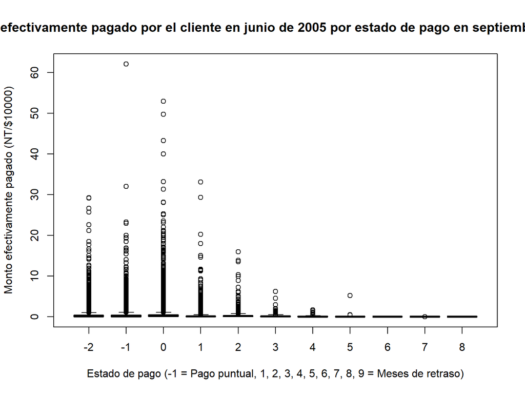

```r
boxplot(PAY_AMT4/10000 ~ PAY_0, data = datos_credit_visu,
        main = "Monto efectivamente pagado por el cliente en junio de 2005 por estado de pago en septiembre de 2005",
        xlab = "Estado de pago (-1 = Pago puntual, 1, 2, 3, 4, 5, 6, 7, 8, 9 = Meses de retraso)", ylab = "Monto efectivamente pagado (NT/$10000)",
        col = "grey90")
```

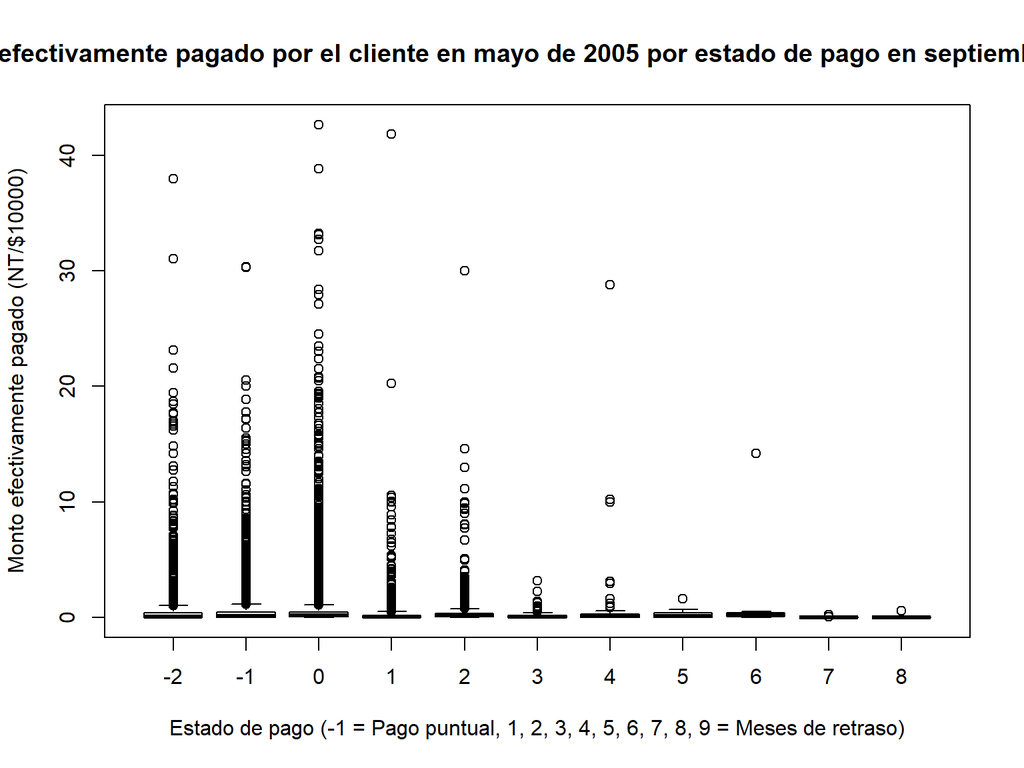

```r
boxplot(PAY_AMT5/10000 ~ PAY_0, data = datos_credit_visu,
        main = "Monto efectivamente pagado por el cliente en mayo de 2005 por estado de pago en septiembre de 2005",
        xlab = "Estado de pago (-1 = Pago puntual, 1, 2, 3, 4, 5, 6, 7, 8, 9 = Meses de retraso)", ylab = "Monto efectivamente pagado (NT/$10000)",
        col = "grey90")
```

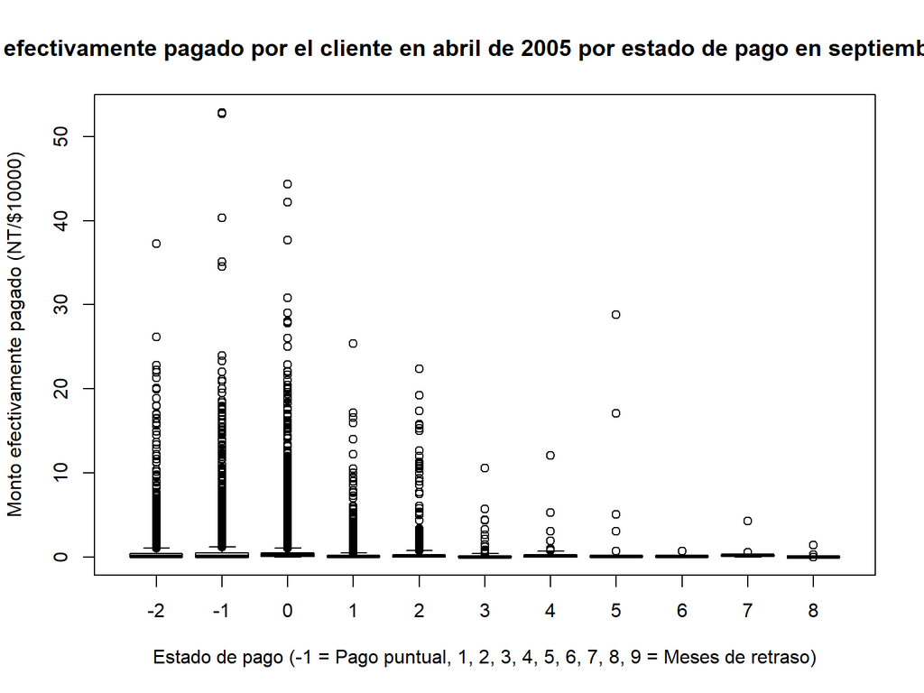

```r
boxplot(PAY_AMT6/10000 ~ PAY_0, data = datos_credit_visu,
        main = "Monto efectivamente pagado por el cliente en abril de 2005 por estado de pago en septiembre de 2005",
        xlab = "Estado de pago (-1 = Pago puntual, 1, 2, 3, 4, 5, 6, 7, 8, 9 = Meses de retraso)", ylab = "Monto efectivamente pagado (NT/$10000)",
        col = "grey90")
```

## 2.7 De PAY_2

En esta sección se cruza `PAY_2` (estado de pago del cliente en agosto de 2005, convertida a factor) contra las mismas variables numéricas, siguiendo la misma lógica de la sección de `PAY_0`.

Se cruza `LIMIT_BAL` contra `PAY_2`, para comparar el monto de crédito otorgado según el estado de pago de agosto de 2005.

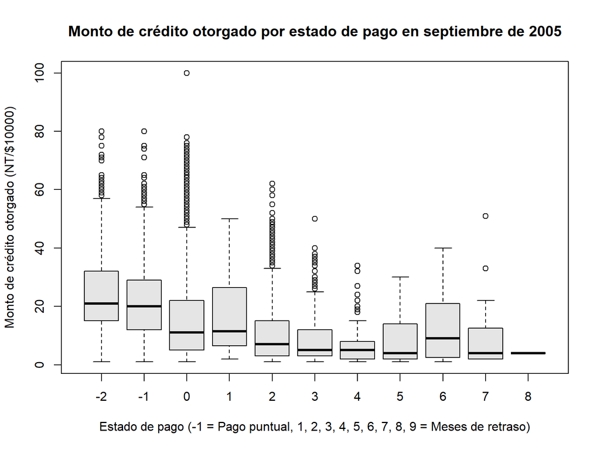

```r
boxplot(LIMIT_BAL/10000 ~ PAY_2, data = datos_credit_visu,
        main = "Monto de crédito otorgado por estado de pago en septiembre de 2005",
        xlab = "Estado de pago (-1 = Pago puntual, 1, 2, 3, 4, 5, 6, 7, 8, 9 = Meses de retraso)", ylab = "Monto de crédito otorgado (NT/$10000)",
        col = "grey90")
```

Se cruza `AGE` contra `PAY_2`, para observar si la edad se relaciona con el estado de pago de agosto de 2005.

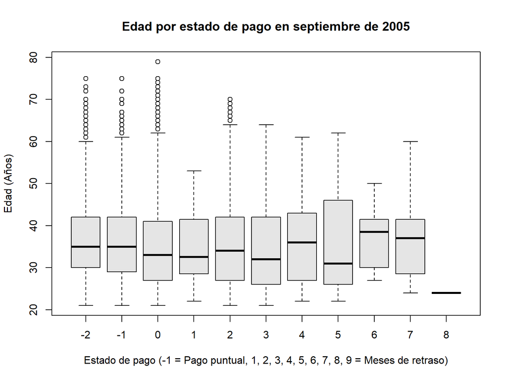

```r
boxplot(AGE ~ PAY_2, data = datos_credit_visu,
        main = "Edad por estado de pago en septiembre de 2005",
        xlab = "Estado de pago (-1 = Pago puntual, 1, 2, 3, 4, 5, 6, 7, 8, 9 = Meses de retraso)", ylab = "Edad (Años)",
        col = "grey90")
```

Se cruzan `BILL_AMT1` a `BILL_AMT6` contra `PAY_2`, generando un boxplot por mes para comparar el monto del estado de cuenta según el estado de pago de agosto de 2005.

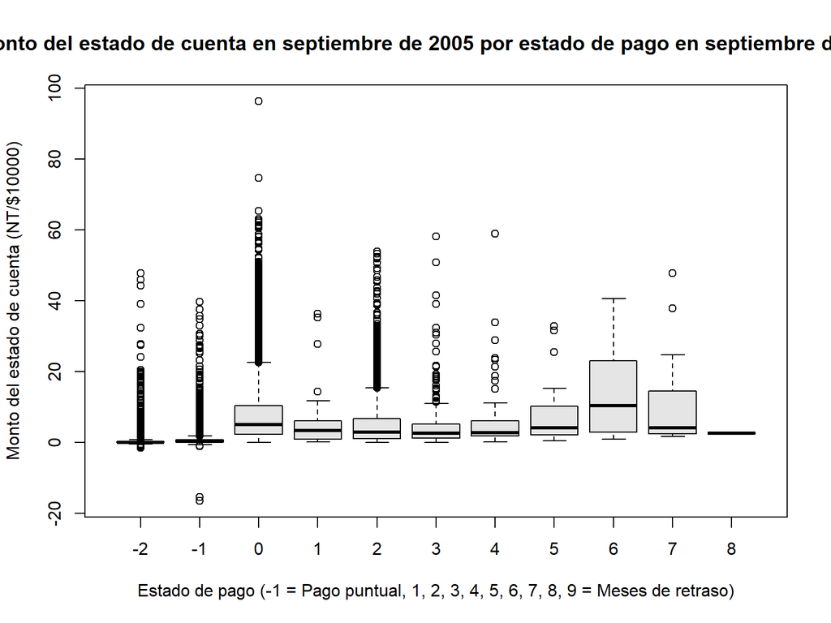

```r
boxplot(BILL_AMT1/10000 ~ PAY_2, data = datos_credit_visu,
        main = "Monto del estado de cuenta en septiembre de 2005 por estado de pago en septiembre de 2005",
        xlab = "Estado de pago (-1 = Pago puntual, 1, 2, 3, 4, 5, 6, 7, 8, 9 = Meses de retraso)", ylab = "Monto del estado de cuenta (NT/$10000)",
        col = "grey90")
```

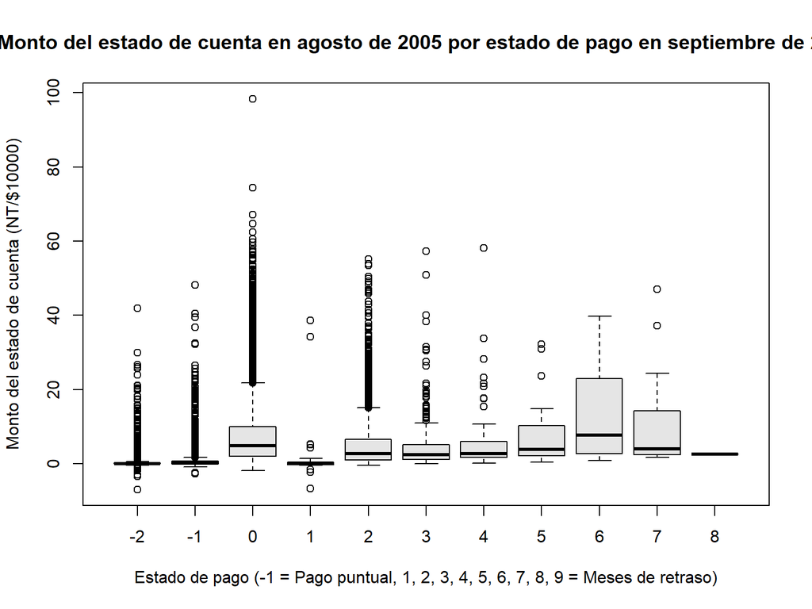

```r
boxplot(BILL_AMT2/10000 ~ PAY_2, data = datos_credit_visu,
        main = "Monto del estado de cuenta en agosto de 2005 por estado de pago en septiembre de 2005",
        xlab = "Estado de pago (-1 = Pago puntual, 1, 2, 3, 4, 5, 6, 7, 8, 9 = Meses de retraso)", ylab = "Monto del estado de cuenta (NT/$10000)",
        col = "grey90")
```

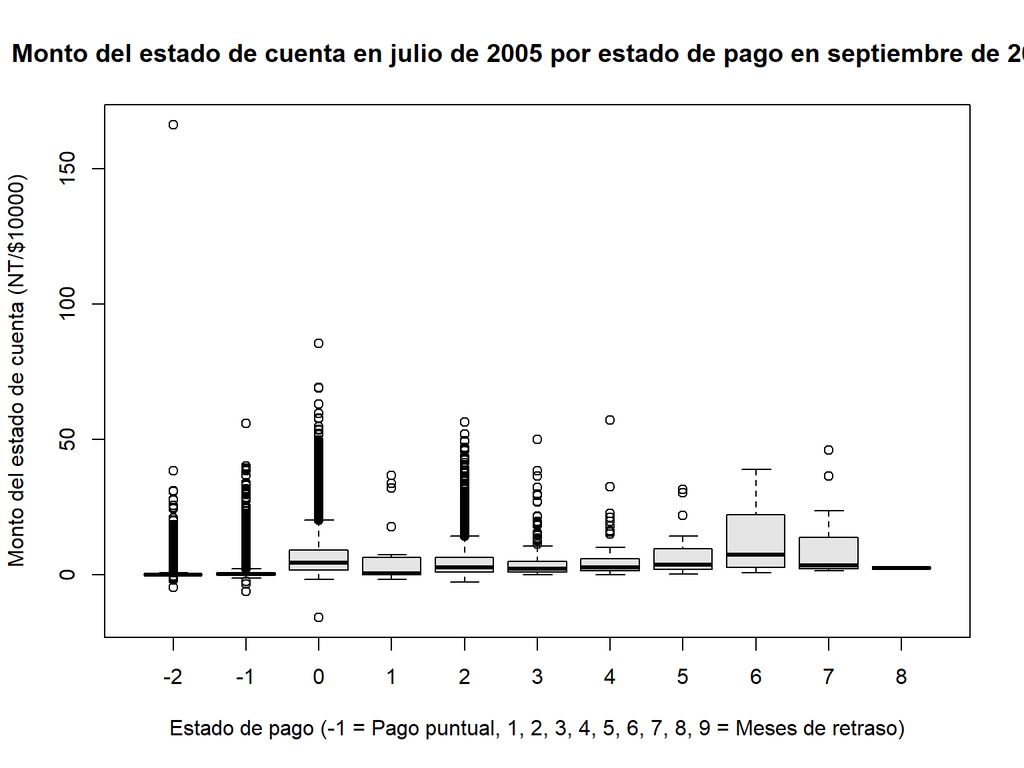

```r
boxplot(BILL_AMT3/10000 ~ PAY_2, data = datos_credit_visu,
        main = "Monto del estado de cuenta en julio de 2005 por estado de pago en septiembre de 2005",
        xlab = "Estado de pago (-1 = Pago puntual, 1, 2, 3, 4, 5, 6, 7, 8, 9 = Meses de retraso)", ylab = "Monto del estado de cuenta (NT/$10000)",
        col = "grey90")
```

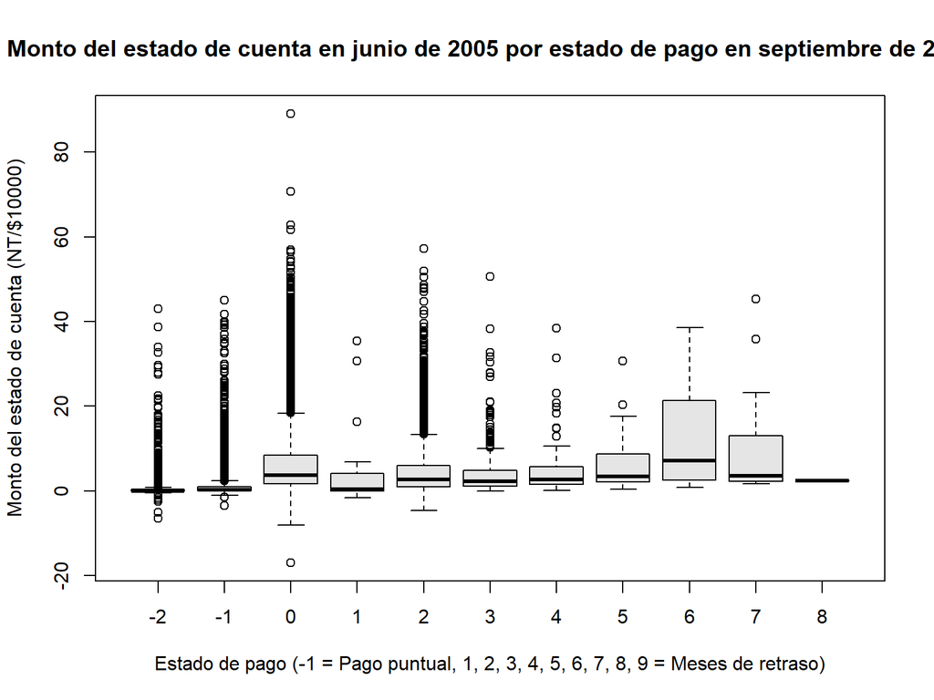

```r
boxplot(BILL_AMT4/10000 ~ PAY_2, data = datos_credit_visu,
        main = "Monto del estado de cuenta en junio de 2005 por estado de pago en septiembre de 2005",
        xlab = "Estado de pago (-1 = Pago puntual, 1, 2, 3, 4, 5, 6, 7, 8, 9 = Meses de retraso)", ylab = "Monto del estado de cuenta (NT/$10000)",
        col = "grey90")
```

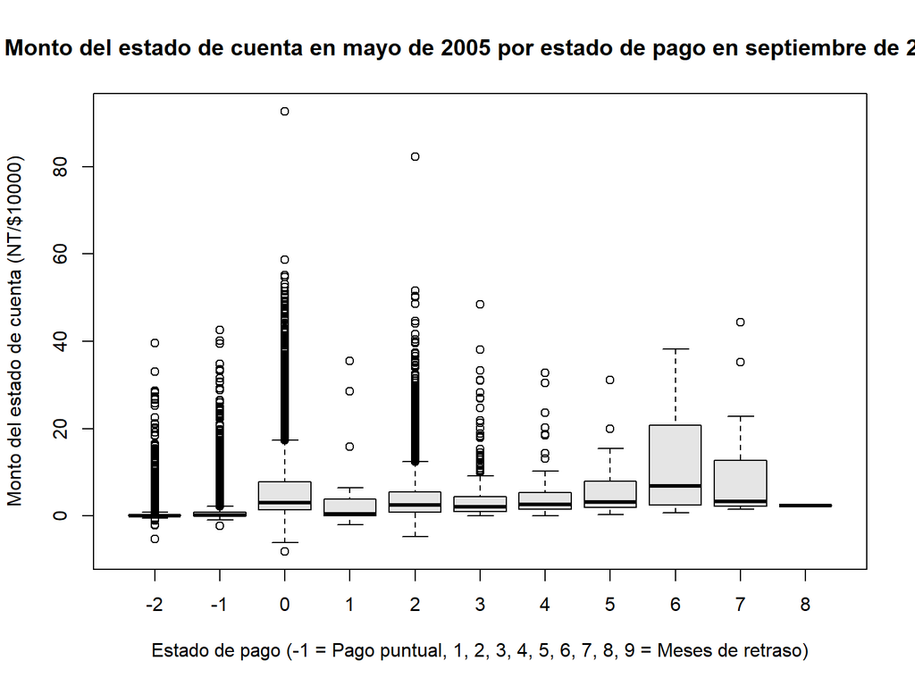

```r
boxplot(BILL_AMT5/10000 ~ PAY_2, data = datos_credit_visu,
        main = "Monto del estado de cuenta en mayo de 2005 por estado de pago en septiembre de 2005",
        xlab = "Estado de pago (-1 = Pago puntual, 1, 2, 3, 4, 5, 6, 7, 8, 9 = Meses de retraso)", ylab = "Monto del estado de cuenta (NT/$10000)",
        col = "grey90")
```

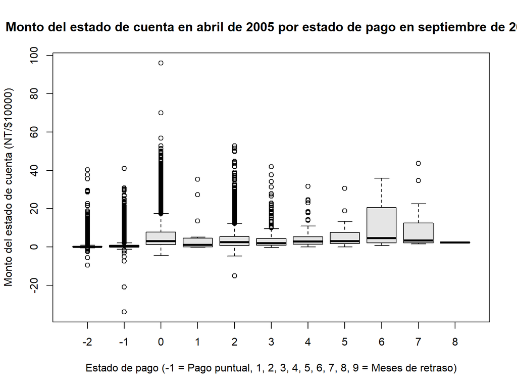

```r
boxplot(BILL_AMT6/10000 ~ PAY_2, data = datos_credit_visu,
        main = "Monto del estado de cuenta en abril de 2005 por estado de pago en septiembre de 2005",
        xlab = "Estado de pago (-1 = Pago puntual, 1, 2, 3, 4, 5, 6, 7, 8, 9 = Meses de retraso)", ylab = "Monto del estado de cuenta (NT/$10000)",
        col = "grey90")
```

Se cruzan `PAY_AMT1` a `PAY_AMT6` contra `PAY_2`, para comparar cuánto pagaron efectivamente los clientes según su estado de pago de agosto de 2005, mes a mes.

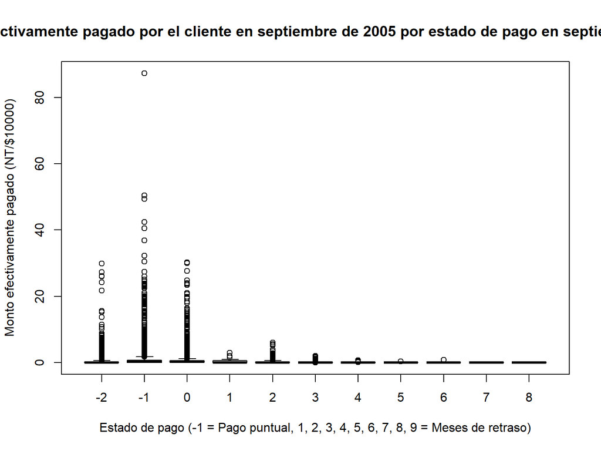

```r
boxplot(PAY_AMT1/10000 ~ PAY_2, data = datos_credit_visu,
        main = "Monto efectivamente pagado por el cliente en septiembre de 2005 por estado de pago en septiembre de 2005",
        xlab = "Estado de pago (-1 = Pago puntual, 1, 2, 3, 4, 5, 6, 7, 8, 9 = Meses de retraso)", ylab = "Monto efectivamente pagado (NT/$10000)",
        col = "grey90")
```

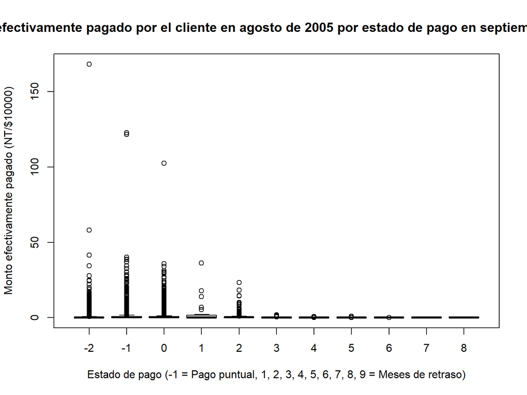

```r
boxplot(PAY_AMT2/10000 ~ PAY_2, data = datos_credit_visu,
        main = "Monto efectivamente pagado por el cliente en agosto de 2005 por estado de pago en septiembre de 2005",
        xlab = "Estado de pago (-1 = Pago puntual, 1, 2, 3, 4, 5, 6, 7, 8, 9 = Meses de retraso)", ylab = "Monto efectivamente pagado (NT/$10000)",
        col = "grey90")
```

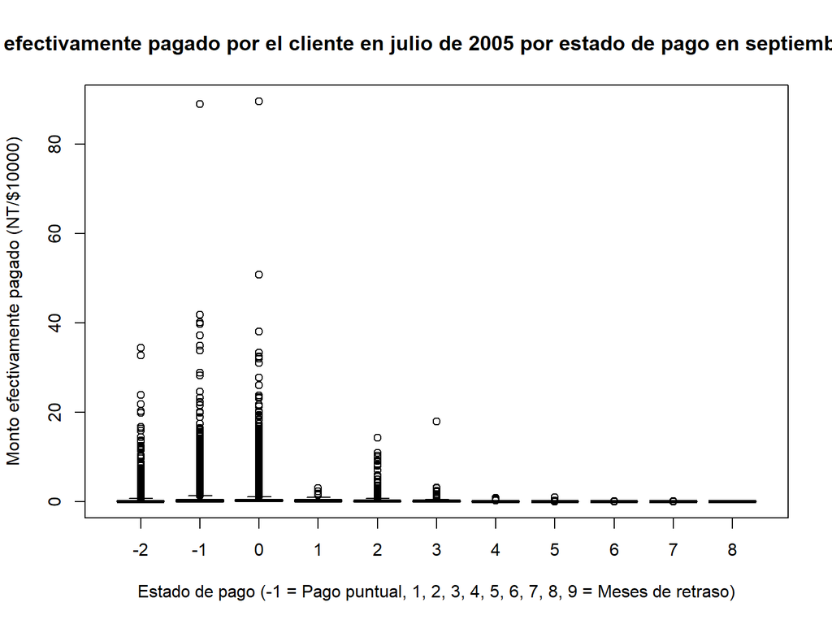

```r
boxplot(PAY_AMT3/10000 ~ PAY_2, data = datos_credit_visu,
        main = "Monto efectivamente pagado por el cliente en julio de 2005 por estado de pago en septiembre de 2005",
        xlab = "Estado de pago (-1 = Pago puntual, 1, 2, 3, 4, 5, 6, 7, 8, 9 = Meses de retraso)", ylab = "Monto efectivamente pagado (NT/$10000)",
        col = "grey90")
```

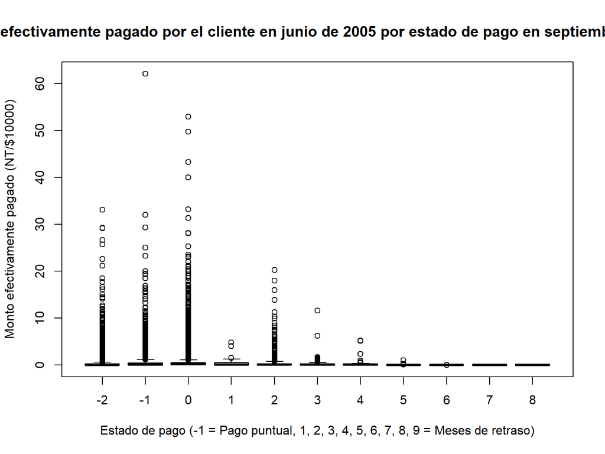

```r
boxplot(PAY_AMT4/10000 ~ PAY_2, data = datos_credit_visu,
        main = "Monto efectivamente pagado por el cliente en junio de 2005 por estado de pago en septiembre de 2005",
        xlab = "Estado de pago (-1 = Pago puntual, 1, 2, 3, 4, 5, 6, 7, 8, 9 = Meses de retraso)", ylab = "Monto efectivamente pagado (NT/$10000)",
        col = "grey90")
```

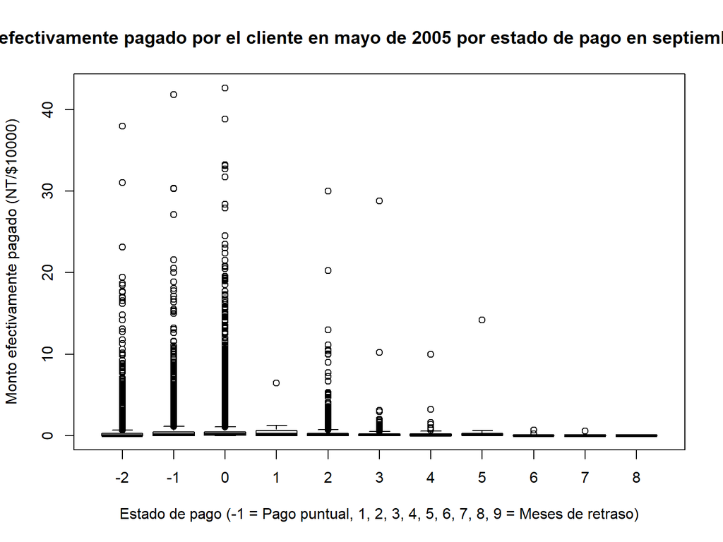

```r
boxplot(PAY_AMT5/10000 ~ PAY_2, data = datos_credit_visu,
        main = "Monto efectivamente pagado por el cliente en mayo de 2005 por estado de pago en septiembre de 2005",
        xlab = "Estado de pago (-1 = Pago puntual, 1, 2, 3, 4, 5, 6, 7, 8, 9 = Meses de retraso)", ylab = "Monto efectivamente pagado (NT/$10000)",
        col = "grey90")
```

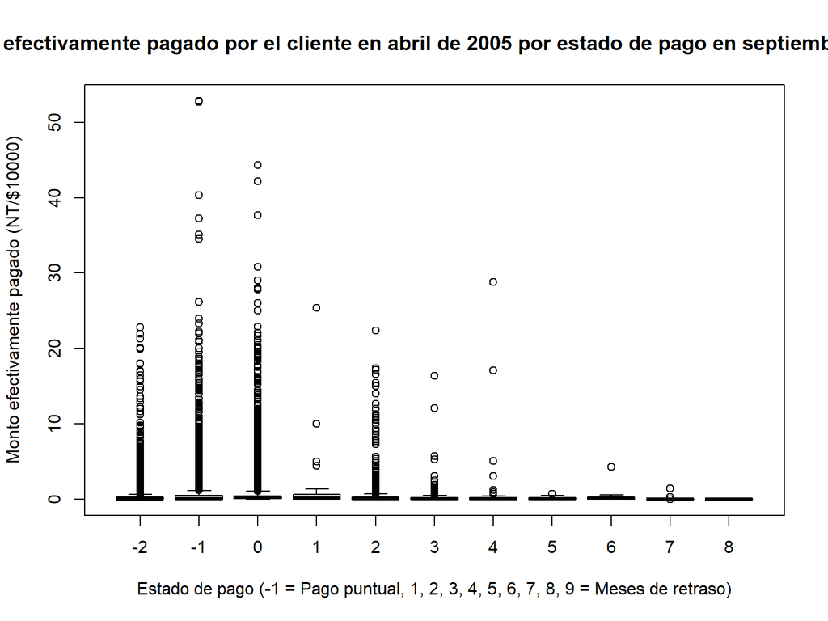

```r
boxplot(PAY_AMT6/10000 ~ PAY_2, data = datos_credit_visu,
        main = "Monto efectivamente pagado por el cliente en abril de 2005 por estado de pago en septiembre de 2005",
        xlab = "Estado de pago (-1 = Pago puntual, 1, 2, 3, 4, 5, 6, 7, 8, 9 = Meses de retraso)", ylab = "Monto efectivamente pagado (NT/$10000)",
        col = "grey90")
```